# Results: Program 1

| Obs | Ogrenci_ID | Yas | Cinsiyet | Nabiz | Kan_Basinci_Sistolik | Kan_Basinci_Diyastolik | Stress_Seviyesi_Biosensor | Stress_Seviyesi_Bildirim | Fiziksel_Aktivite | Uyku_Kalitesi | Ruh_Hali | Ders_Saatleri | Proje_Saatleri | Saglik_Riski_Seviyesi |
| --- | --- | --- | --- | --- | --- | --- | --- | --- | --- | --- | --- | --- | --- | --- |
| 1 | 1 | 24 | 1 | 50.663216989 | 122.17301497 | 84.419860064 | 3.1373497465 | 9.0286691598 | 3 | 2 | 3 | 34.520972885 | 16.800956391 | 2 |
| 2 | 2 | 21 | 0 | 57.926041684 | 110.77840702 | 75.696145236 | 3.699078337 | 5.8196972448 | 2 | 3 | 1 | 16.763846015 | 15.791154348 | 2 |
| 3 | 3 | 22 | 1 | 59.294219203 | 109.37567306 | 83.803814482 | 6.7851556346 | 5.8923601742 | 1 | 2 | 3 | 44.20379848 | 25.678437047 | 2 |
| 4 | 4 | 24 | 1 | 76.826232365 | 125.14222744 | 78.091586814 | 6.4085093608 | 6.8840013066 | 3 | 1 | 3 | 21.776645286 | 20.808391157 | 3 |
| 5 | 5 | 20 | 1 | 68.342769469 | 107.51559175 | 80.674936812 | 7.2647187541 | 4.4834501074 | 2 | 1 | 3 | 8.9649990827 | 15.194045002 | 2 |
| 6 | 6 | 22 | 1 | 61.74415157 | 90 | 84.450864714 | 4.2625178608 | 6.8250005506 | 2 | 3 | 3 | 44.948228999 | 15.651195419 | 2 |
| 7 | 7 | 22 | 0 | 93.097227554 | 106.67778156 | 76.499815454 | 8.4159788669 | 1.4029154982 | 2 | 2 | 3 | 10.26985 | 23.818096039 | 2 |
| 8 | 8 | 24 | 0 | 63.361030865 | 115.39678277 | 70.03950214 | 2.8367889504 | 1.4864286461 | 1 | 3 | 2 | 39.641787734 | 19.31543893 | 1 |
| 9 | 9 | 19 | 0 | 81.671029144 | 142.82097747 | 74.676877341 | 5.2213667277 | 5.1150737766 | 2 | 2 | 2 | 37.211195209 | 8.8549856975 | 2 |
| 10 | 10 | 20 | 1 | 86.211085578 | 112.63593825 | 91.951391798 | 8.2084484939 | 5.94660071 | 2 | 2 | 3 | 33.195541012 | 19.744741114 | 2 |

The CONTENTS Procedure

| Data Set Name | WORK.IMPORT | Observations | 300 |
| --- | --- | --- | --- |
| Member Type | DATA | Variables | 14 |
| Engine | V9 | Indexes | 0 |
| Created | 31.12.2025 21:19:08 | Observation Length | 112 |
| Last Modified | 31.12.2025 21:19:08 | Deleted Observations | 0 |
| Protection |  | Compressed | NO |
| Data Set Type |  | Sorted | NO |
| Label |  |  |  |
| Data Representation | SOLARIS_X86_64, LINUX_X86_64, ALPHA_TRU64, LINUX_IA64 |  |  |
| Encoding | utf-8 Unicode (UTF-8) |  |  |

| Engine/Host Dependent Information |  |
| --- | --- |
| Data Set Page Size | 131072 |
| Number of Data Set Pages | 1 |
| First Data Page | 1 |
| Max Obs per Page | 1168 |
| Obs in First Data Page | 300 |
| Number of Data Set Repairs | 0 |
| Filename | /saswork/SAS_work01EF0000C7BE_odaws01-euw1.oda.sas.com/SAS_work435E0000C7BE_odaws01-euw1.oda.sas.com/import.sas7bdat |
| Release Created | 9.0401M8 |
| Host Created | Linux |
| Inode Number | 536871041 |
| Access Permission | rw-r--r-- |
| Owner Name | u64407848 |
| File Size | 256KB |
| File Size (bytes) | 262144 |

| Alphabetic List of Variables and Attributes # | Alphabetic List of Variables and Attributes Variable | Alphabetic List of Variables and Attributes Type | Alphabetic List of Variables and Attributes Len | Alphabetic List of Variables and Attributes Format | Alphabetic List of Variables and Attributes Label |
| --- | --- | --- | --- | --- | --- |
| 3 | Cinsiyet | Num | 8 | BEST. | Cinsiyet |
| 12 | Ders_Saatleri | Num | 8 | BEST. | Ders_Saatleri |
| 9 | Fiziksel_Aktivite | Num | 8 | BEST. | Fiziksel_Aktivite |
| 6 | Kan_Basinci_Diyastolik | Num | 8 | BEST. | Kan_Basinci_Diyastolik |
| 5 | Kan_Basinci_Sistolik | Num | 8 | BEST. | Kan_Basinci_Sistolik |
| 4 | Nabiz | Num | 8 | BEST. | Nabiz |
| 1 | Ogrenci_ID | Num | 8 | BEST. | Ogrenci_ID |
| 13 | Proje_Saatleri | Num | 8 | BEST. | Proje_Saatleri |
| 11 | Ruh_Hali | Num | 8 | BEST. | Ruh_Hali |
| 14 | Saglik_Riski_Seviyesi | Num | 8 | BEST. | Saglik_Riski_Seviyesi |
| 8 | Stress_Seviyesi_Bildirim | Num | 8 | BEST. | Stress_Seviyesi_Bildirim |
| 7 | Stress_Seviyesi_Biosensor | Num | 8 | BEST. | Stress_Seviyesi_Biosensor |
| 10 | Uyku_Kalitesi | Num | 8 | BEST. | Uyku_Kalitesi |
| 2 | Yas | Num | 8 | BEST. | Yas |

The MEANS Procedure

| Variable | Label | N | Mean | Std Dev | Minimum | Maximum |
| --- | --- | --- | --- | --- | --- | --- |
| Yas Nabiz Kan_Basinci_Sistolik Kan_Basinci_Diyastolik Stress_Seviyesi_Biosensor Stress_Seviyesi_Bildirim Ders_Saatleri Proje_Saatleri | Yas Nabiz Kan_Basinci_Sistolik Kan_Basinci_Diyastolik Stress_Seviyesi_Biosensor Stress_Seviyesi_Bildirim Ders_Saatleri Proje_Saatleri | 300 300 300 300 300 300 300 300 | 21.0400000 70.3906615 119.6431419 79.4830408 5.4326214 5.4801849 29.6662245 14.9235631 | 2.0145956 9.3499300 14.9685758 9.1942546 2.5355282 2.5699925 10.1883369 5.1613980 | 18.0000000 50.0000000 90.0000000 60.0000000 1.0084907 1.0021864 5.0000000 0 | 24.0000000 99.6501035 160.7391986 104.1004865 9.8618903 9.9288297 59.8632938 32.7203251 |

The FREQ Procedure

| Cinsiyet | Cinsiyet Frequency | Cinsiyet Percent | Cinsiyet Cumulative Frequency | Cinsiyet Cumulative Percent |
| --- | --- | --- | --- | --- |
| 0 | 148 | 49.33 | 148 | 49.33 |
| 1 | 152 | 50.67 | 300 | 100.00 |

| Fiziksel_Aktivite | Fiziksel_Aktivite Frequency | Fiziksel_Aktivite Percent | Fiziksel_Aktivite Cumulative Frequency | Fiziksel_Aktivite Cumulative Percent |
| --- | --- | --- | --- | --- |
| 1 | 93 | 31.00 | 93 | 31.00 |
| 2 | 147 | 49.00 | 240 | 80.00 |
| 3 | 60 | 20.00 | 300 | 100.00 |

| Uyku_Kalitesi | Uyku_Kalitesi Frequency | Uyku_Kalitesi Percent | Uyku_Kalitesi Cumulative Frequency | Uyku_Kalitesi Cumulative Percent |
| --- | --- | --- | --- | --- |
| 1 | 57 | 19.00 | 57 | 19.00 |
| 2 | 101 | 33.67 | 158 | 52.67 |
| 3 | 142 | 47.33 | 300 | 100.00 |

| Ruh_Hali | Ruh_Hali Frequency | Ruh_Hali Percent | Ruh_Hali Cumulative Frequency | Ruh_Hali Cumulative Percent |
| --- | --- | --- | --- | --- |
| 1 | 56 | 18.67 | 56 | 18.67 |
| 2 | 128 | 42.67 | 184 | 61.33 |
| 3 | 116 | 38.67 | 300 | 100.00 |

| Saglik_Riski_Seviyesi | Saglik_Riski_Seviyesi Frequency | Saglik_Riski_Seviyesi Percent | Saglik_Riski_Seviyesi Cumulative Frequency | Saglik_Riski_Seviyesi Cumulative Percent |
| --- | --- | --- | --- | --- |
| 1 | 53 | 17.67 | 53 | 17.67 |
| 2 | 207 | 69.00 | 260 | 86.67 |
| 3 | 40 | 13.33 | 300 | 100.00 |

The CORR Procedure

| 8 Variables: | Yas Nabiz Kan_Basinci_Sistolik Kan_Basinci_Diyastolik Stress_Seviyesi_Biosensor Stress_Seviyesi_Bildirim Ders_Saatleri Proje_Saatleri |
| --- | --- |

| Simple Statistics Variable | Simple Statistics N | Simple Statistics Mean | Simple Statistics Std Dev | Simple Statistics Sum | Simple Statistics Minimum | Simple Statistics Maximum | Simple Statistics Label |
| --- | --- | --- | --- | --- | --- | --- | --- |
| Yas | 300 | 21.04000 | 2.01460 | 6312 | 18.00000 | 24.00000 | Yas |
| Nabiz | 300 | 70.39066 | 9.34993 | 21117 | 50.00000 | 99.65010 | Nabiz |
| Kan_Basinci_Sistolik | 300 | 119.64314 | 14.96858 | 35893 | 90.00000 | 160.73920 | Kan_Basinci_Sistolik |
| Kan_Basinci_Diyastolik | 300 | 79.48304 | 9.19425 | 23845 | 60.00000 | 104.10049 | Kan_Basinci_Diyastolik |
| Stress_Seviyesi_Biosensor | 300 | 5.43262 | 2.53553 | 1630 | 1.00849 | 9.86189 | Stress_Seviyesi_Biosensor |
| Stress_Seviyesi_Bildirim | 300 | 5.48018 | 2.56999 | 1644 | 1.00219 | 9.92883 | Stress_Seviyesi_Bildirim |
| Ders_Saatleri | 300 | 29.66622 | 10.18834 | 8900 | 5.00000 | 59.86329 | Ders_Saatleri |
| Proje_Saatleri | 300 | 14.92356 | 5.16140 | 4477 | 0 | 32.72033 | Proje_Saatleri |

| Pearson Correlation Coefficients, N = 300 Prob > \|r\| under H0: Rho=0 | Pearson Correlation Coefficients, N = 300 Prob > \|r\| under H0: Rho=0 Yas | Pearson Correlation Coefficients, N = 300 Prob > \|r\| under H0: Rho=0 Nabiz | Pearson Correlation Coefficients, N = 300 Prob > \|r\| under H0: Rho=0 Kan_Basinci_Sistolik | Pearson Correlation Coefficients, N = 300 Prob > \|r\| under H0: Rho=0 Kan_Basinci_Diyastolik | Pearson Correlation Coefficients, N = 300 Prob > \|r\| under H0: Rho=0 Stress_Seviyesi_Biosensor | Pearson Correlation Coefficients, N = 300 Prob > \|r\| under H0: Rho=0 Stress_Seviyesi_Bildirim | Pearson Correlation Coefficients, N = 300 Prob > \|r\| under H0: Rho=0 Ders_Saatleri | Pearson Correlation Coefficients, N = 300 Prob > \|r\| under H0: Rho=0 Proje_Saatleri |
| --- | --- | --- | --- | --- | --- | --- | --- | --- |
| Yas Yas | 1.00000 | -0.08768 0.1297 | -0.06143 0.2889 | 0.12176 0.0350 | 0.01869 0.7471 | 0.00577 0.9208 | -0.11235 0.0519 | -0.08617 0.1365 |
| Nabiz Nabiz | -0.08768 0.1297 | 1.00000 | -0.03418 0.5554 | -0.09802 0.0901 | 0.18328 0.0014 | 0.00521 0.9284 | 0.01714 0.7675 | -0.00405 0.9443 |
| Kan_Basinci_Sistolik Kan_Basinci_Sistolik | -0.06143 0.2889 | -0.03418 0.5554 | 1.00000 | 0.02470 0.6701 | -0.07622 0.1880 | -0.02964 0.6091 | 0.00802 0.8899 | -0.06746 0.2440 |
| Kan_Basinci_Diyastolik Kan_Basinci_Diyastolik | 0.12176 0.0350 | -0.09802 0.0901 | 0.02470 0.6701 | 1.00000 | -0.07688 0.1842 | 0.00315 0.9567 | -0.06011 0.2994 | 0.00900 0.8766 |
| Stress_Seviyesi_Biosensor Stress_Seviyesi_Biosensor | 0.01869 0.7471 | 0.18328 0.0014 | -0.07622 0.1880 | -0.07688 0.1842 | 1.00000 | -0.04298 0.4583 | -0.16189 0.0049 | 0.07510 0.1945 |
| Stress_Seviyesi_Bildirim Stress_Seviyesi_Bildirim | 0.00577 0.9208 | 0.00521 0.9284 | -0.02964 0.6091 | 0.00315 0.9567 | -0.04298 0.4583 | 1.00000 | 0.08427 0.1453 | -0.04574 0.4300 |
| Ders_Saatleri Ders_Saatleri | -0.11235 0.0519 | 0.01714 0.7675 | 0.00802 0.8899 | -0.06011 0.2994 | -0.16189 0.0049 | 0.08427 0.1453 | 1.00000 | -0.00697 0.9043 |
| Proje_Saatleri Proje_Saatleri | -0.08617 0.1365 | -0.00405 0.9443 | -0.06746 0.2440 | 0.00900 0.8766 | 0.07510 0.1945 | -0.04574 0.4300 | -0.00697 0.9043 | 1.00000 |

The CLUSTER Procedure

Ward's Minimum Variance Cluster Analysis

| Variable | Mean | Standard Deviation | Skewness | Kurtosis | Bimodality |
| --- | --- | --- | --- | --- | --- |
| Yas | 21.0400 | 2.0146 | -0.0229 | -1.2158 | 0.5514 |
| Nabiz | 70.3907 | 9.3499 | 0.1703 | 0.1316 | 0.3254 |
| Kan_Basinci_Sistolik | 119.6 | 14.9686 | 0.1394 | -0.3592 | 0.3816 |
| Kan_Basinci_Diyastolik | 79.4830 | 9.1943 | 0.1411 | -0.3090 | 0.3748 |
| Stress_Seviyesi_Biosensor | 5.4326 | 2.5355 | 0.0275 | -1.1389 | 0.5291 |
| Stress_Seviyesi_Bildirim | 5.4802 | 2.5700 | 0.0212 | -1.2139 | 0.5508 |
| Ders_Saatleri | 29.6662 | 10.1883 | -0.00005 | -0.0651 | 0.3372 |
| Proje_Saatleri | 14.9236 | 5.1614 | 0.0400 | 0.3372 | 0.2974 |

| Eigenvalues of the Covariance Matrix | Eigenvalues of the Covariance Matrix Eigenvalue | Eigenvalues of the Covariance Matrix Difference | Eigenvalues of the Covariance Matrix Proportion | Eigenvalues of the Covariance Matrix Cumulative |
| --- | --- | --- | --- | --- |
| 1 | 224.532942 | 118.133193 | 0.4131 | 0.4131 |
| 2 | 106.399749 | 13.710843 | 0.1958 | 0.6088 |
| 3 | 92.688906 | 15.663463 | 0.1705 | 0.7794 |
| 4 | 77.025443 | 50.426607 | 0.1417 | 0.9211 |
| 5 | 26.598836 | 20.027483 | 0.0489 | 0.9700 |
| 6 | 6.571353 | 0.696268 | 0.0121 | 0.9821 |
| 7 | 5.875085 | 2.019029 | 0.0108 | 0.9929 |
| 8 | 3.856055 |  | 0.0071 | 1.0000 |

| Root-Mean-Square Total-Sample Standard Deviation | 8.242788 |
| --- | --- |

| Root-Mean-Square Distance Between Observations | 32.97115 |
| --- | --- |

| Cluster History Number of Clusters | Cluster History Clusters Joined | Cluster History Clusters Joined | Cluster History Freq | Cluster History New Cluster RMS Std Dev | Cluster History Semipartial R-Square | Cluster History R-Square | Cluster History Tie |
| --- | --- | --- | --- | --- | --- | --- | --- |
| 299 | 101 | 114 | 2 | 0.7913 | 0.0000 | 1.00 |  |
| 298 | 115 | 195 | 2 | 1.2218 | 0.0001 | 1.00 |  |
| 297 | 132 | 252 | 2 | 1.3975 | 0.0001 | 1.00 |  |
| 296 | 146 | 184 | 2 | 1.4090 | 0.0001 | 1.00 |  |
| 295 | 278 | 300 | 2 | 1.4509 | 0.0001 | 1.00 |  |
| 294 | 215 | 287 | 2 | 1.4706 | 0.0001 | .999 |  |
| 293 | 84 | 200 | 2 | 1.4753 | 0.0001 | .999 |  |
| 292 | 54 | 281 | 2 | 1.4837 | 0.0001 | .999 |  |
| 291 | 273 | 293 | 2 | 1.4877 | 0.0001 | .999 |  |
| 290 | 126 | 151 | 2 | 1.5121 | 0.0001 | .999 |  |
| 289 | 119 | 177 | 2 | 1.5725 | 0.0001 | .999 |  |
| 288 | 69 | 107 | 2 | 1.5769 | 0.0001 | .999 |  |
| 287 | 142 | 261 | 2 | 1.5825 | 0.0001 | .999 |  |
| 286 | 17 | 120 | 2 | 1.6045 | 0.0001 | .999 |  |
| 285 | 95 | 242 | 2 | 1.6652 | 0.0001 | .998 |  |
| 284 | 60 | 280 | 2 | 1.6725 | 0.0001 | .998 |  |
| 283 | 206 | 247 | 2 | 1.6808 | 0.0001 | .998 |  |
| 282 | 12 | 170 | 2 | 1.7457 | 0.0002 | .998 |  |
| 281 | 125 | 157 | 2 | 1.7831 | 0.0002 | .998 |  |
| 280 | 192 | 288 | 2 | 1.8027 | 0.0002 | .998 |  |
| 279 | 16 | 277 | 2 | 1.8096 | 0.0002 | .998 |  |
| 278 | 67 | 111 | 2 | 1.8278 | 0.0002 | .997 |  |
| 277 | 4 | 239 | 2 | 1.8386 | 0.0002 | .997 |  |
| 276 | 22 | 47 | 2 | 1.8489 | 0.0002 | .997 |  |
| 275 | 53 | 87 | 2 | 1.8643 | 0.0002 | .997 |  |
| 274 | 18 | 230 | 2 | 1.8853 | 0.0002 | .997 |  |
| 273 | 14 | 205 | 2 | 1.9161 | 0.0002 | .996 |  |
| 272 | CL293 | 98 | 3 | 1.7105 | 0.0002 | .996 |  |
| 271 | 56 | 131 | 2 | 1.9197 | 0.0002 | .996 |  |
| 270 | 168 | 272 | 2 | 1.9251 | 0.0002 | .996 |  |

[output cut: 269 more lines]

The TREE Procedure

Ward's Minimum Variance Cluster Analysis

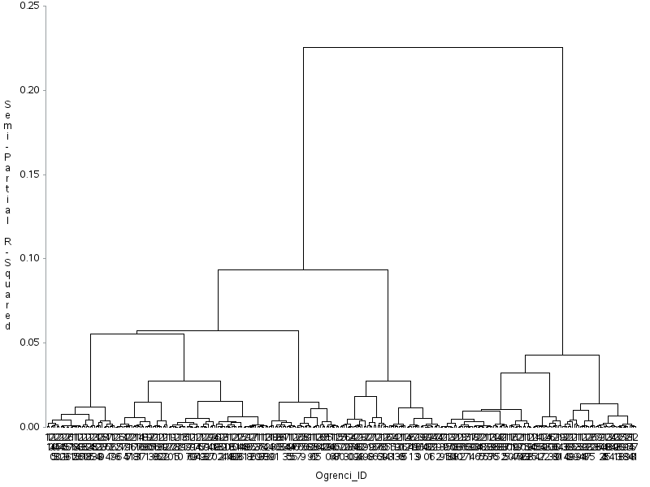

The CLUSTER Procedure

Average Linkage Cluster Analysis

| Eigenvalues of the Covariance Matrix | Eigenvalues of the Covariance Matrix Eigenvalue | Eigenvalues of the Covariance Matrix Difference | Eigenvalues of the Covariance Matrix Proportion | Eigenvalues of the Covariance Matrix Cumulative |
| --- | --- | --- | --- | --- |
| 1 | 224.532942 | 118.133193 | 0.4131 | 0.4131 |
| 2 | 106.399749 | 13.710843 | 0.1958 | 0.6088 |
| 3 | 92.688906 | 15.663463 | 0.1705 | 0.7794 |
| 4 | 77.025443 | 50.426607 | 0.1417 | 0.9211 |
| 5 | 26.598836 | 20.027483 | 0.0489 | 0.9700 |
| 6 | 6.571353 | 0.696268 | 0.0121 | 0.9821 |
| 7 | 5.875085 | 2.019029 | 0.0108 | 0.9929 |
| 8 | 3.856055 |  | 0.0071 | 1.0000 |

| Root-Mean-Square Total-Sample Standard Deviation | 8.242788 |
| --- | --- |

| Root-Mean-Square Distance Between Observations | 32.97115 |
| --- | --- |

| Cluster History Number of Clusters | Cluster History Clusters Joined | Cluster History Clusters Joined | Cluster History Freq | Cluster History Norm RMS Distance | Cluster History Tie |
| --- | --- | --- | --- | --- | --- |
| 299 | 101 | 114 | 2 | 0.096 |  |
| 298 | 115 | 195 | 2 | 0.1482 |  |
| 297 | 132 | 252 | 2 | 0.1695 |  |
| 296 | 146 | 184 | 2 | 0.1709 |  |
| 295 | 278 | 300 | 2 | 0.176 |  |
| 294 | 215 | 287 | 2 | 0.1784 |  |
| 293 | 84 | 200 | 2 | 0.179 |  |
| 292 | 54 | 281 | 2 | 0.18 |  |
| 291 | 273 | 293 | 2 | 0.1805 |  |
| 290 | 126 | 151 | 2 | 0.1834 |  |
| 289 | 119 | 177 | 2 | 0.1908 |  |
| 288 | 69 | 107 | 2 | 0.1913 |  |
| 287 | 142 | 261 | 2 | 0.192 |  |
| 286 | 17 | 120 | 2 | 0.1947 |  |
| 285 | 95 | 242 | 2 | 0.202 |  |
| 284 | 60 | 280 | 2 | 0.2029 |  |
| 283 | 206 | 247 | 2 | 0.2039 |  |
| 282 | 12 | 170 | 2 | 0.2118 |  |
| 281 | 125 | 157 | 2 | 0.2163 |  |
| 280 | 192 | 288 | 2 | 0.2187 |  |
| 279 | 16 | 277 | 2 | 0.2195 |  |
| 278 | CL293 | 98 | 3 | 0.2204 |  |
| 277 | 67 | 111 | 2 | 0.2217 |  |
| 276 | 4 | 239 | 2 | 0.2231 |  |
| 275 | 22 | 47 | 2 | 0.2243 |  |
| 274 | 53 | 87 | 2 | 0.2262 |  |
| 273 | 18 | 230 | 2 | 0.2287 |  |
| 272 | 14 | 205 | 2 | 0.2325 |  |
| 271 | 56 | 131 | 2 | 0.2329 |  |
| 270 | CL292 | 99 | 3 | 0.233 |  |

[output cut: 269 more lines]

The CLUSTER Procedure

Complete Linkage Cluster Analysis

| Eigenvalues of the Covariance Matrix | Eigenvalues of the Covariance Matrix Eigenvalue | Eigenvalues of the Covariance Matrix Difference | Eigenvalues of the Covariance Matrix Proportion | Eigenvalues of the Covariance Matrix Cumulative |
| --- | --- | --- | --- | --- |
| 1 | 224.532942 | 118.133193 | 0.4131 | 0.4131 |
| 2 | 106.399749 | 13.710843 | 0.1958 | 0.6088 |
| 3 | 92.688906 | 15.663463 | 0.1705 | 0.7794 |
| 4 | 77.025443 | 50.426607 | 0.1417 | 0.9211 |
| 5 | 26.598836 | 20.027483 | 0.0489 | 0.9700 |
| 6 | 6.571353 | 0.696268 | 0.0121 | 0.9821 |
| 7 | 5.875085 | 2.019029 | 0.0108 | 0.9929 |
| 8 | 3.856055 |  | 0.0071 | 1.0000 |

| Root-Mean-Square Total-Sample Standard Deviation | 8.242788 |
| --- | --- |

| Mean Distance Between Observations | 31.06846 |
| --- | --- |

| Cluster History Number of Clusters | Cluster History Clusters Joined | Cluster History Clusters Joined | Cluster History Freq | Cluster History Norm Maximum Distance | Cluster History Tie |
| --- | --- | --- | --- | --- | --- |
| 299 | 101 | 114 | 2 | 0.1019 |  |
| 298 | 115 | 195 | 2 | 0.1573 |  |
| 297 | 132 | 252 | 2 | 0.1799 |  |
| 296 | 146 | 184 | 2 | 0.1814 |  |
| 295 | 278 | 300 | 2 | 0.1868 |  |
| 294 | 215 | 287 | 2 | 0.1893 |  |
| 293 | 84 | 200 | 2 | 0.1899 |  |
| 292 | 54 | 281 | 2 | 0.191 |  |
| 291 | 273 | 293 | 2 | 0.1915 |  |
| 290 | 126 | 151 | 2 | 0.1947 |  |
| 289 | 119 | 177 | 2 | 0.2025 |  |
| 288 | 69 | 107 | 2 | 0.203 |  |
| 287 | 142 | 261 | 2 | 0.2037 |  |
| 286 | 17 | 120 | 2 | 0.2066 |  |
| 285 | 95 | 242 | 2 | 0.2144 |  |
| 284 | 60 | 280 | 2 | 0.2153 |  |
| 283 | 206 | 247 | 2 | 0.2164 |  |
| 282 | 12 | 170 | 2 | 0.2248 |  |
| 281 | 125 | 157 | 2 | 0.2296 |  |
| 280 | 192 | 288 | 2 | 0.2321 |  |
| 279 | 16 | 277 | 2 | 0.233 |  |
| 278 | 67 | 111 | 2 | 0.2353 |  |
| 277 | 4 | 239 | 2 | 0.2367 |  |
| 276 | 22 | 47 | 2 | 0.238 |  |
| 275 | 53 | 87 | 2 | 0.24 |  |
| 274 | CL293 | 98 | 3 | 0.2419 |  |
| 273 | 18 | 230 | 2 | 0.2427 |  |
| 272 | 14 | 205 | 2 | 0.2467 |  |
| 271 | 56 | 131 | 2 | 0.2472 |  |
| 270 | 168 | 272 | 2 | 0.2479 |  |

[output cut: 269 more lines]

The CLUSTER Procedure

Single Linkage Cluster Analysis

| Eigenvalues of the Covariance Matrix | Eigenvalues of the Covariance Matrix Eigenvalue | Eigenvalues of the Covariance Matrix Difference | Eigenvalues of the Covariance Matrix Proportion | Eigenvalues of the Covariance Matrix Cumulative |
| --- | --- | --- | --- | --- |
| 1 | 224.532942 | 118.133193 | 0.4131 | 0.4131 |
| 2 | 106.399749 | 13.710843 | 0.1958 | 0.6088 |
| 3 | 92.688906 | 15.663463 | 0.1705 | 0.7794 |
| 4 | 77.025443 | 50.426607 | 0.1417 | 0.9211 |
| 5 | 26.598836 | 20.027483 | 0.0489 | 0.9700 |
| 6 | 6.571353 | 0.696268 | 0.0121 | 0.9821 |
| 7 | 5.875085 | 2.019029 | 0.0108 | 0.9929 |
| 8 | 3.856055 |  | 0.0071 | 1.0000 |

| Root-Mean-Square Total-Sample Standard Deviation | 8.242788 |
| --- | --- |

| Mean Distance Between Observations | 31.06846 |
| --- | --- |

| Cluster History Number of Clusters | Cluster History Clusters Joined | Cluster History Clusters Joined | Cluster History Freq | Cluster History Norm Minimum Distance | Cluster History Tie |
| --- | --- | --- | --- | --- | --- |
| 299 | 101 | 114 | 2 | 0.1019 |  |
| 298 | 115 | 195 | 2 | 0.1573 |  |
| 297 | 132 | 252 | 2 | 0.1799 |  |
| 296 | 146 | 184 | 2 | 0.1814 |  |
| 295 | 278 | 300 | 2 | 0.1868 |  |
| 294 | 215 | 287 | 2 | 0.1893 |  |
| 293 | 84 | 200 | 2 | 0.1899 |  |
| 292 | 54 | 281 | 2 | 0.191 |  |
| 291 | 273 | 293 | 2 | 0.1915 |  |
| 290 | 126 | 151 | 2 | 0.1947 |  |
| 289 | 68 | CL297 | 3 | 0.1953 |  |
| 288 | CL292 | 99 | 3 | 0.198 |  |
| 287 | 119 | 177 | 2 | 0.2025 |  |
| 286 | 69 | 107 | 2 | 0.203 |  |
| 285 | 142 | 261 | 2 | 0.2037 |  |
| 284 | 17 | 120 | 2 | 0.2066 |  |
| 283 | 95 | 242 | 2 | 0.2144 |  |
| 282 | 121 | CL291 | 3 | 0.2147 |  |
| 281 | 60 | 280 | 2 | 0.2153 |  |
| 280 | 206 | 247 | 2 | 0.2164 |  |
| 279 | CL285 | 185 | 3 | 0.2223 |  |
| 278 | CL288 | 256 | 4 | 0.2231 |  |
| 277 | 12 | 170 | 2 | 0.2248 |  |
| 276 | CL293 | 98 | 3 | 0.2256 |  |
| 275 | 187 | CL295 | 3 | 0.2273 |  |
| 274 | 76 | CL282 | 4 | 0.2274 |  |
| 273 | 125 | 157 | 2 | 0.2296 |  |
| 272 | 192 | 288 | 2 | 0.2321 |  |
| 271 | CL273 | 268 | 3 | 0.2326 |  |
| 270 | 16 | 277 | 2 | 0.233 |  |

[output cut: 269 more lines]

The CLUSTER Procedure

Centroid Hierarchical Cluster Analysis

| Eigenvalues of the Covariance Matrix | Eigenvalues of the Covariance Matrix Eigenvalue | Eigenvalues of the Covariance Matrix Difference | Eigenvalues of the Covariance Matrix Proportion | Eigenvalues of the Covariance Matrix Cumulative |
| --- | --- | --- | --- | --- |
| 1 | 224.532942 | 118.133193 | 0.4131 | 0.4131 |
| 2 | 106.399749 | 13.710843 | 0.1958 | 0.6088 |
| 3 | 92.688906 | 15.663463 | 0.1705 | 0.7794 |
| 4 | 77.025443 | 50.426607 | 0.1417 | 0.9211 |
| 5 | 26.598836 | 20.027483 | 0.0489 | 0.9700 |
| 6 | 6.571353 | 0.696268 | 0.0121 | 0.9821 |
| 7 | 5.875085 | 2.019029 | 0.0108 | 0.9929 |
| 8 | 3.856055 |  | 0.0071 | 1.0000 |

| Root-Mean-Square Total-Sample Standard Deviation | 8.242788 |
| --- | --- |

| Root-Mean-Square Distance Between Observations | 32.97115 |
| --- | --- |

| Cluster History Number of Clusters | Cluster History Clusters Joined | Cluster History Clusters Joined | Cluster History Freq | Cluster History Norm Centroid Distance | Cluster History Tie |
| --- | --- | --- | --- | --- | --- |
| 299 | 101 | 114 | 2 | 0.096 |  |
| 298 | 115 | 195 | 2 | 0.1482 |  |
| 297 | 132 | 252 | 2 | 0.1695 |  |
| 296 | 146 | 184 | 2 | 0.1709 |  |
| 295 | 278 | 300 | 2 | 0.176 |  |
| 294 | 215 | 287 | 2 | 0.1784 |  |
| 293 | 84 | 200 | 2 | 0.179 |  |
| 292 | 54 | 281 | 2 | 0.18 |  |
| 291 | 273 | 293 | 2 | 0.1805 |  |
| 290 | 126 | 151 | 2 | 0.1834 |  |
| 289 | 119 | 177 | 2 | 0.1908 |  |
| 288 | 69 | 107 | 2 | 0.1913 |  |
| 287 | 142 | 261 | 2 | 0.192 |  |
| 286 | 17 | 120 | 2 | 0.1947 |  |
| 285 | CL293 | 98 | 3 | 0.2014 |  |
| 284 | 95 | 242 | 2 | 0.202 |  |
| 283 | 60 | 280 | 2 | 0.2029 |  |
| 282 | 206 | 247 | 2 | 0.2039 |  |
| 281 | 12 | 170 | 2 | 0.2118 |  |
| 280 | CL292 | 99 | 3 | 0.2149 |  |
| 279 | 125 | 157 | 2 | 0.2163 |  |
| 278 | 192 | 288 | 2 | 0.2187 |  |
| 277 | 68 | CL297 | 3 | 0.2188 |  |
| 276 | 16 | 277 | 2 | 0.2195 |  |
| 275 | CL279 | 183 | 3 | 0.2217 |  |
| 274 | 67 | 111 | 2 | 0.2217 |  |
| 273 | 121 | CL291 | 3 | 0.2219 |  |
| 272 | 4 | 239 | 2 | 0.2231 |  |
| 271 | 22 | 47 | 2 | 0.2243 |  |
| 270 | CL275 | 268 | 4 | 0.2259 |  |

[output cut: 269 more lines]

The CLUSTER Procedure

Ward's Minimum Variance Cluster Analysis

| Eigenvalues of the Covariance Matrix | Eigenvalues of the Covariance Matrix Eigenvalue | Eigenvalues of the Covariance Matrix Difference | Eigenvalues of the Covariance Matrix Proportion | Eigenvalues of the Covariance Matrix Cumulative |
| --- | --- | --- | --- | --- |
| 1 | 219.721679 | 112.553070 | 0.4074 | 0.4074 |
| 2 | 107.168609 | 14.550870 | 0.1987 | 0.6061 |
| 3 | 92.617739 | 15.976637 | 0.1717 | 0.7778 |
| 4 | 76.641102 | 49.790318 | 0.1421 | 0.9199 |
| 5 | 26.850784 | 20.228919 | 0.0498 | 0.9697 |
| 6 | 6.621865 | 0.783744 | 0.0123 | 0.9820 |
| 7 | 5.838121 | 1.966501 | 0.0108 | 0.9928 |
| 8 | 3.871619 |  | 0.0072 | 1.0000 |

| Root-Mean-Square Total-Sample Standard Deviation | 8.210751 |
| --- | --- |

| Root-Mean-Square Distance Between Observations | 32.84301 |
| --- | --- |

| Cluster History Number of Clusters | Cluster History Clusters Joined | Cluster History Clusters Joined | Cluster History Freq | Cluster History Semipartial R-Square | Cluster History R-Square | Cluster History Tie |
| --- | --- | --- | --- | --- | --- | --- |
| 296 | 101 | 114 | 2 | 0.0000 | 1.00 |  |
| 295 | 115 | 195 | 2 | 0.0001 | 1.00 |  |
| 294 | 132 | 252 | 2 | 0.0001 | 1.00 |  |
| 293 | 146 | 184 | 2 | 0.0001 | 1.00 |  |
| 292 | 278 | 300 | 2 | 0.0001 | 1.00 |  |
| 291 | 215 | 287 | 2 | 0.0001 | .999 |  |
| 290 | 54 | 281 | 2 | 0.0001 | .999 |  |
| 289 | 273 | 293 | 2 | 0.0001 | .999 |  |
| 288 | 126 | 151 | 2 | 0.0001 | .999 |  |
| 287 | 119 | 177 | 2 | 0.0001 | .999 |  |
| 286 | 69 | 107 | 2 | 0.0001 | .999 |  |
| 285 | 142 | 261 | 2 | 0.0001 | .999 |  |
| 284 | 17 | 120 | 2 | 0.0001 | .999 |  |
| 283 | 95 | 242 | 2 | 0.0001 | .999 |  |
| 282 | 60 | 280 | 2 | 0.0001 | .998 |  |
| 281 | 206 | 247 | 2 | 0.0001 | .998 |  |
| 280 | 12 | 170 | 2 | 0.0002 | .998 |  |
| 279 | 84 | 98 | 2 | 0.0002 | .998 |  |
| 278 | 125 | 157 | 2 | 0.0002 | .998 |  |
| 277 | 192 | 288 | 2 | 0.0002 | .998 |  |
| 276 | 16 | 277 | 2 | 0.0002 | .997 |  |
| 275 | 67 | 111 | 2 | 0.0002 | .997 |  |
| 274 | 4 | 239 | 2 | 0.0002 | .997 |  |
| 273 | 22 | 47 | 2 | 0.0002 | .997 |  |
| 272 | 53 | 87 | 2 | 0.0002 | .997 |  |
| 271 | 18 | 230 | 2 | 0.0002 | .997 |  |
| 270 | 14 | 205 | 2 | 0.0002 | .996 |  |
| 269 | 56 | 131 | 2 | 0.0002 | .996 |  |
| 268 | 168 | 272 | 2 | 0.0002 | .996 |  |
| 267 | 21 | 191 | 2 | 0.0002 | .996 |  |

[output cut: 266 more lines]

The TREE Procedure

Ward's Minimum Variance Cluster Analysis

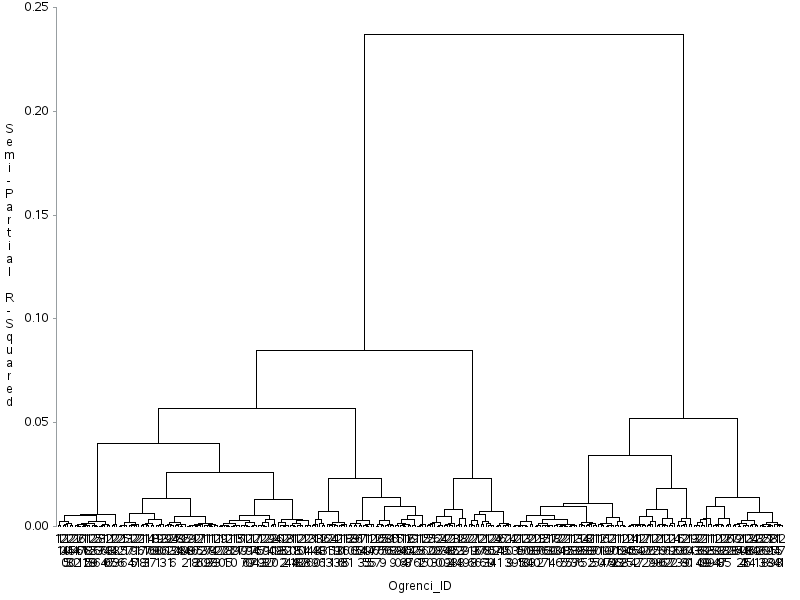

The FASTCLUS Procedure

Replace=FULL Radius=0 Maxclusters=3 Maxiter=100 Converge=0.02

| Initial Seeds Cluster | Initial Seeds Yas | Initial Seeds Nabiz | Initial Seeds Kan_Basinci_Sistolik | Initial Seeds Kan_Basinci_Diyastolik | Initial Seeds Stress_Seviyesi_Biosensor | Initial Seeds Stress_Seviyesi_Bildirim | Initial Seeds Ders_Saatleri | Initial Seeds Proje_Saatleri |
| --- | --- | --- | --- | --- | --- | --- | --- | --- |
| 1 | 24.0000000 | 61.2886624 | 93.8422783 | 74.0609683 | 2.1815917 | 3.2702755 | 39.7412337 | 12.7936860 |
| 2 | 24.0000000 | 50.0000000 | 155.0124537 | 84.8487868 | 5.7254441 | 2.4547392 | 9.0813591 | 7.8995851 |
| 3 | 19.0000000 | 99.6501035 | 152.8123324 | 81.7983108 | 7.6659722 | 4.7336217 | 41.5203870 | 15.8604644 |

| Minimum Distance Between Initial Seeds = | 60.24038 |
| --- | --- |

| Iteration History Iteration | Iteration History Criterion | Iteration History Relative Change in Cluster Seeds 1 | Iteration History Relative Change in Cluster Seeds 2 | Iteration History Relative Change in Cluster Seeds 3 |
| --- | --- | --- | --- | --- |
| 1 | 11.1601 | 0.3786 | 0.4691 | 0.4767 |
| 2 | 6.8205 | 0.0221 | 0.0377 | 0.0316 |
| 3 | 6.7743 | 0.0225 | 0.0227 | 0.0422 |
| 4 | 6.7304 | 0.00812 | 0.0228 | 0.0248 |
| 5 | 6.7139 | 0.00596 | 0.0150 | 0.0135 |

| Convergence criterion is satisfied. |
| --- |

| Cluster Listing Obs | Cluster Listing Ogrenci_ID | Cluster Listing Cluster | Cluster Listing Distance from Seed |
| --- | --- | --- | --- |
| 1 | 1 | 2 | 22.9949 |
| 2 | 2 | 1 | 19.0265 |
| 3 | 3 | 1 | 20.8317 |
| 4 | 4 | 2 | 14.7550 |
| 5 | 5 | 1 | 21.8616 |
| 6 | 6 | 1 | 25.1393 |
| 7 | 7 | 1 | 32.3928 |
| 8 | 8 | 1 | 17.6687 |
| 9 | 9 | 3 | 13.9132 |
| 10 | 10 | 1 | 21.9060 |
| 11 | 11 | 2 | 15.1372 |
| 12 | 12 | 1 | 15.9326 |
| 13 | 13 | 3 | 15.3714 |
| 14 | 14 | 2 | 7.6259 |
| 15 | 15 | 3 | 11.2036 |
| 16 | 16 | 1 | 20.3974 |
| 17 | 17 | 3 | 15.6157 |
| 18 | 18 | 2 | 10.7260 |
| 19 | 19 | 3 | 12.4370 |
| 20 | 20 | 2 | 19.4614 |
| 21 | 21 | 2 | 17.9570 |
| 22 | 22 | 1 | 14.8301 |
| 23 | 23 | 1 | 22.0934 |
| 24 | 24 | 1 | 9.7212 |
| 25 | 25 | 3 | 31.2588 |
| 26 | 26 | 1 | 15.4230 |
| 27 | 27 | 1 | 32.6012 |
| 28 | 28 | 3 | 17.5274 |
| 29 | 29 | 2 | 12.5552 |
| 30 | 30 | 2 | 12.5052 |

[output cut: 270 more lines]

| Criterion Based on Final Seeds = | 6.7083 |
| --- | --- |

| Cluster Summary Cluster | Cluster Summary Frequency | Cluster Summary RMS Std Deviation | Cluster Summary Maximum Distance from Seed to Observation | Cluster Summary Radius Exceeded | Cluster Summary Nearest Cluster | Cluster Summary Distance Between Cluster Centroids |
| --- | --- | --- | --- | --- | --- | --- |
| 1 | 152 | 7.1755 | 32.9049 |  | 3 | 24.9853 |
| 2 | 73 | 6.3464 | 32.1338 |  | 3 | 17.6604 |
| 3 | 75 | 6.1674 | 33.0596 |  | 2 | 17.6604 |

| Statistics for Variables Variable | Statistics for Variables Total STD | Statistics for Variables Within STD | Statistics for Variables R-Square | Statistics for Variables RSQ/(1-RSQ) |
| --- | --- | --- | --- | --- |
| Yas | 2.01460 | 1.99658 | 0.024374 | 0.024983 |
| Nabiz | 9.34993 | 8.89922 | 0.100144 | 0.111289 |
| Kan_Basinci_Sistolik | 14.96858 | 9.02968 | 0.638532 | 1.766500 |
| Kan_Basinci_Diyastolik | 9.19425 | 8.99179 | 0.049954 | 0.052581 |
| Stress_Seviyesi_Biosensor | 2.53553 | 2.54042 | 0.002850 | 0.002858 |
| Stress_Seviyesi_Bildirim | 2.56999 | 2.57576 | 0.002227 | 0.002232 |
| Ders_Saatleri | 10.18834 | 8.84553 | 0.251268 | 0.335591 |
| Proje_Saatleri | 5.16140 | 5.14269 | 0.013875 | 0.014070 |
| OVER-ALL | 8.24279 | 6.73933 | 0.335995 | 0.506014 |

| Pseudo F Statistic = | 75.14 |
| --- | --- |

| Approximate Expected Over-All R-Squared = | 0.42272 |
| --- | --- |

| Cubic Clustering Criterion = | -6.793 |
| --- | --- |

WARNING: The two values above are invalid for correlated variables.

| Cluster Means Cluster | Cluster Means Yas | Cluster Means Nabiz | Cluster Means Kan_Basinci_Sistolik | Cluster Means Kan_Basinci_Diyastolik | Cluster Means Stress_Seviyesi_Biosensor | Cluster Means Stress_Seviyesi_Bildirim | Cluster Means Ders_Saatleri | Cluster Means Proje_Saatleri |
| --- | --- | --- | --- | --- | --- | --- | --- | --- |
| 1 | 21.0986842 | 70.0516752 | 107.8606235 | 79.1982121 | 5.5227870 | 5.4074138 | 30.4390383 | 15.3055334 |
| 2 | 21.4246575 | 66.5049324 | 131.9004878 | 82.7066926 | 5.1963686 | 5.4163446 | 21.6020885 | 15.2059078 |
| 3 | 20.5466667 | 74.8597835 | 131.5918959 | 76.9226058 | 5.4798384 | 5.6898055 | 35.9490808 | 13.8746212 |

| Cluster Standard Deviations Cluster | Cluster Standard Deviations Yas | Cluster Standard Deviations Nabiz | Cluster Standard Deviations Kan_Basinci_Sistolik | Cluster Standard Deviations Kan_Basinci_Diyastolik | Cluster Standard Deviations Stress_Seviyesi_Biosensor | Cluster Standard Deviations Stress_Seviyesi_Bildirim | Cluster Standard Deviations Ders_Saatleri | Cluster Standard Deviations Proje_Saatleri |
| --- | --- | --- | --- | --- | --- | --- | --- | --- |
| 1 | 2.00581891 | 9.50410293 | 8.59337765 | 9.65537955 | 2.57824824 | 2.63946701 | 10.39408923 | 5.36906472 |
| 2 | 1.99942914 | 8.30437350 | 9.08108267 | 8.98584219 | 2.35337020 | 2.52496432 | 6.79150480 | 5.29230847 |
| 3 | 1.97479615 | 8.15097356 | 9.81423483 | 7.46368366 | 2.63616048 | 2.49171266 | 6.97847051 | 4.48025999 |

| Distance Between Cluster Centroids Nearest Cluster | Distance Between Cluster Centroids 1 | Distance Between Cluster Centroids 2 | Distance Between Cluster Centroids 3 |
| --- | --- | --- | --- |
| 1 | . | 26.09824487 | 24.98527509 |
| 2 | 26.09824487 | . | 17.66037771 |
| 3 | 24.98527509 | 17.66037771 | . |

| Obs | Ogrenci_ID | CLUSTER | DISTANCE |
| --- | --- | --- | --- |
| 1 | 1 | 2 | 22.9949 |
| 2 | 2 | 1 | 19.0265 |
| 3 | 3 | 1 | 20.8317 |
| 4 | 4 | 2 | 14.7550 |
| 5 | 5 | 1 | 21.8616 |
| 6 | 6 | 1 | 25.1393 |
| 7 | 7 | 1 | 32.3928 |
| 8 | 8 | 1 | 17.6687 |
| 9 | 9 | 3 | 13.9132 |
| 10 | 10 | 1 | 21.9060 |
| 11 | 11 | 2 | 15.1372 |
| 12 | 12 | 1 | 15.9326 |
| 13 | 13 | 3 | 15.3714 |
| 14 | 14 | 2 | 7.6259 |
| 15 | 15 | 3 | 11.2036 |
| 16 | 16 | 1 | 20.3974 |
| 17 | 17 | 3 | 15.6157 |
| 18 | 18 | 2 | 10.7260 |
| 19 | 19 | 3 | 12.4370 |
| 20 | 20 | 2 | 19.4614 |

The FREQ Procedure

| Cluster CLUSTER | Cluster Frequency | Cluster Percent | Cluster Cumulative Frequency | Cluster Cumulative Percent |
| --- | --- | --- | --- | --- |
| 1 | 152 | 50.67 | 152 | 50.67 |
| 2 | 73 | 24.33 | 225 | 75.00 |
| 3 | 75 | 25.00 | 300 | 100.00 |

The MEANS Procedure

| Cluster | N Obs | Variable | Label | N | Mean | Std Dev | Minimum | Maximum |
| --- | --- | --- | --- | --- | --- | --- | --- | --- |
| 1 | 152 | Yas Nabiz Kan_Basinci_Sistolik Kan_Basinci_Diyastolik Stress_Seviyesi_Biosensor Stress_Seviyesi_Bildirim Ders_Saatleri Proje_Saatleri | Yas Nabiz Kan_Basinci_Sistolik Kan_Basinci_Diyastolik Stress_Seviyesi_Biosensor Stress_Seviyesi_Bildirim Ders_Saatleri Proje_Saatleri | 152 152 152 152 152 152 152 152 | 21.0986842 70.0516752 107.8606235 79.1982121 5.5227870 5.4074138 30.4390383 15.3055334 | 2.0058189 9.5041029 8.5933776 9.6553796 2.5782482 2.6394670 10.3940892 5.3690647 | 18.0000000 50.0000000 90.0000000 60.0000000 1.0084907 1.0021864 5.0000000 0 | 24.0000000 99.3775285 121.2376905 103.5020580 9.7955544 9.8438717 59.8632938 30.7482401 |
| 2 | 73 | Yas Nabiz Kan_Basinci_Sistolik Kan_Basinci_Diyastolik Stress_Seviyesi_Biosensor Stress_Seviyesi_Bildirim Ders_Saatleri Proje_Saatleri | Yas Nabiz Kan_Basinci_Sistolik Kan_Basinci_Diyastolik Stress_Seviyesi_Biosensor Stress_Seviyesi_Bildirim Ders_Saatleri Proje_Saatleri | 73 73 73 73 73 73 73 73 | 21.4246575 66.5049324 131.9004878 82.7066926 5.1963686 5.4163446 21.6020885 15.2059078 | 1.9994291 8.3043735 9.0810827 8.9858422 2.3533702 2.5249643 6.7915048 5.2923085 | 18.0000000 50.0000000 117.6060816 60.0000000 1.1890824 1.2805742 5.0429262 4.5522515 | 24.0000000 82.1450929 155.0124537 104.1004865 9.6731667 9.8943590 36.2963760 32.7203251 |
| 3 | 75 | Yas Nabiz Kan_Basinci_Sistolik Kan_Basinci_Diyastolik Stress_Seviyesi_Biosensor Stress_Seviyesi_Bildirim Ders_Saatleri Proje_Saatleri | Yas Nabiz Kan_Basinci_Sistolik Kan_Basinci_Diyastolik Stress_Seviyesi_Biosensor Stress_Seviyesi_Bildirim Ders_Saatleri Proje_Saatleri | 75 75 75 75 75 75 75 75 | 20.5466667 74.8597835 131.5918959 76.9226058 5.4798384 5.6898055 35.9490808 13.8746212 | 1.9747961 8.1509736 9.8142348 7.4636837 2.6361605 2.4917127 6.9784705 4.4802600 | 18.0000000 55.5850575 118.0122498 62.1305427 1.0544234 1.1998253 22.8833846 0.8868252 | 24.0000000 99.6501035 160.7391986 93.7040969 9.8618903 9.9288297 57.1361978 23.0226396 |

The GLM Procedure

| Class Level Information Class | Class Level Information Levels | Class Level Information Values |
| --- | --- | --- |
| CLUSTER | 3 | 1 2 3 |

| Number of Observations Read | 300 |
| --- | --- |
| Number of Observations Used | 300 |

The GLM Procedure

Dependent Variable: Yas Yas

| Source | DF | Sum of Squares | Mean Square | F Value | Pr > F |
| --- | --- | --- | --- | --- | --- |
| Model | 2 | 29.577980 | 14.788990 | 3.71 | 0.0256 |
| Error | 297 | 1183.942020 | 3.986337 |  |  |
| Corrected Total | 299 | 1213.520000 |  |  |  |

| R-Square | Coeff Var | Root MSE | Yas Mean |
| --- | --- | --- | --- |
| 0.024374 | 9.489455 | 1.996581 | 21.04000 |

| Source | DF | Type I SS | Mean Square | F Value | Pr > F |
| --- | --- | --- | --- | --- | --- |
| CLUSTER | 2 | 29.57798005 | 14.78899003 | 3.71 | 0.0256 |

| Source | DF | Type III SS | Mean Square | F Value | Pr > F |
| --- | --- | --- | --- | --- | --- |
| CLUSTER | 2 | 29.57798005 | 14.78899003 | 3.71 | 0.0256 |

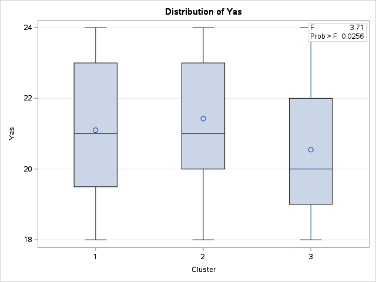

The GLM Procedure

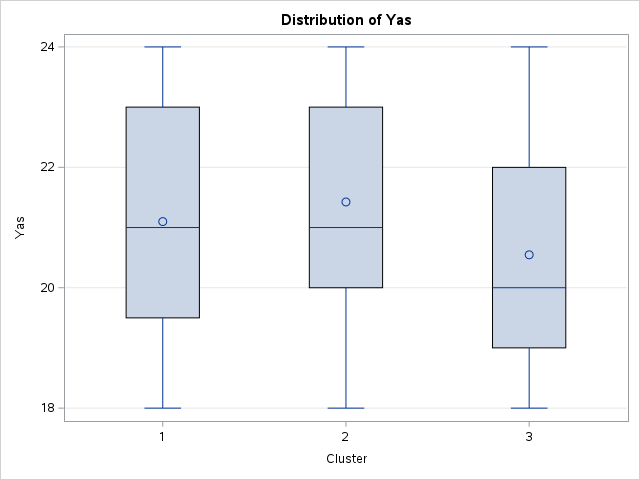

The GLM Procedure

Tukey's Studentized Range (HSD) Test for Yas

Note:This test controls the Type I experimentwise error rate.

| Alpha | 0.05 |
| --- | --- |
| Error Degrees of Freedom | 297 |
| Error Mean Square | 3.986337 |
| Critical Value of Studentized Range | 3.33122 |

| Comparisons significant at the 0.05 level are indicated by ***. CLUSTER Comparison | Comparisons significant at the 0.05 level are indicated by ***. Difference Between Means | Comparisons significant at the 0.05 level are indicated by ***. Simultaneous 95% Confidence Limits | Comparisons significant at the 0.05 level are indicated by ***. Simultaneous 95% Confidence Limits | Comparisons significant at the 0.05 level are indicated by ***. |
| --- | --- | --- | --- | --- |
| 2 - 1 | 0.3260 | -0.3437 | 0.9957 |  |
| 2 - 3 | 0.8780 | 0.1048 | 1.6512 | *** |
| 1 - 2 | -0.3260 | -0.9957 | 0.3437 |  |
| 1 - 3 | 0.5520 | -0.1116 | 1.2157 |  |
| 3 - 2 | -0.8780 | -1.6512 | -0.1048 | *** |
| 3 - 1 | -0.5520 | -1.2157 | 0.1116 |  |

The GLM Procedure

| Class Level Information Class | Class Level Information Levels | Class Level Information Values |
| --- | --- | --- |
| CLUSTER | 3 | 1 2 3 |

| Number of Observations Read | 300 |
| --- | --- |
| Number of Observations Used | 300 |

The GLM Procedure

Dependent Variable: Nabiz Nabiz

| Source | DF | Sum of Squares | Mean Square | F Value | Pr > F |
| --- | --- | --- | --- | --- | --- |
| Model | 2 | 2617.66442 | 1308.83221 | 16.53 | <.0001 |
| Error | 297 | 23521.27182 | 79.19620 |  |  |
| Corrected Total | 299 | 26138.93624 |  |  |  |

| R-Square | Coeff Var | Root MSE | Nabiz Mean |
| --- | --- | --- | --- |
| 0.100144 | 12.64262 | 8.899225 | 70.39066 |

| Source | DF | Type I SS | Mean Square | F Value | Pr > F |
| --- | --- | --- | --- | --- | --- |
| CLUSTER | 2 | 2617.664421 | 1308.832210 | 16.53 | <.0001 |

| Source | DF | Type III SS | Mean Square | F Value | Pr > F |
| --- | --- | --- | --- | --- | --- |
| CLUSTER | 2 | 2617.664421 | 1308.832210 | 16.53 | <.0001 |

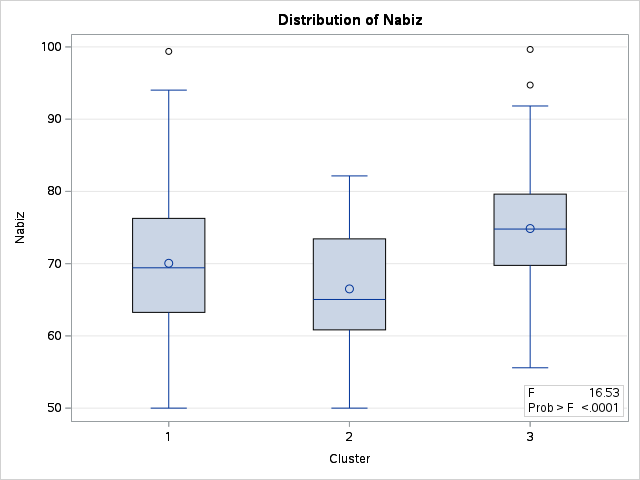

The GLM Procedure

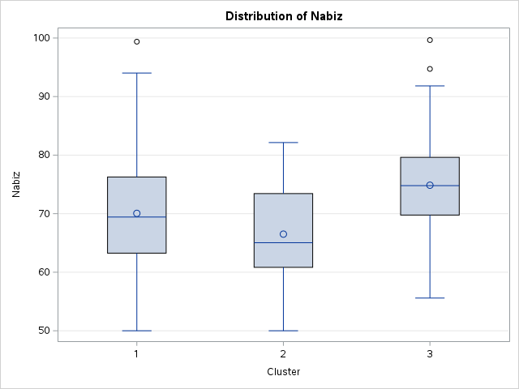

The GLM Procedure

Tukey's Studentized Range (HSD) Test for Nabiz

Note:This test controls the Type I experimentwise error rate.

| Alpha | 0.05 |
| --- | --- |
| Error Degrees of Freedom | 297 |
| Error Mean Square | 79.1962 |
| Critical Value of Studentized Range | 3.33122 |

| Comparisons significant at the 0.05 level are indicated by ***. CLUSTER Comparison | Comparisons significant at the 0.05 level are indicated by ***. Difference Between Means | Comparisons significant at the 0.05 level are indicated by ***. Simultaneous 95% Confidence Limits | Comparisons significant at the 0.05 level are indicated by ***. Simultaneous 95% Confidence Limits | Comparisons significant at the 0.05 level are indicated by ***. |
| --- | --- | --- | --- | --- |
| 3 - 1 | 4.808 | 1.850 | 7.766 | *** |
| 3 - 2 | 8.355 | 4.908 | 11.801 | *** |
| 1 - 3 | -4.808 | -7.766 | -1.850 | *** |
| 1 - 2 | 3.547 | 0.562 | 6.532 | *** |
| 2 - 3 | -8.355 | -11.801 | -4.908 | *** |
| 2 - 1 | -3.547 | -6.532 | -0.562 | *** |

The GLM Procedure

| Class Level Information Class | Class Level Information Levels | Class Level Information Values |
| --- | --- | --- |
| CLUSTER | 3 | 1 2 3 |

| Number of Observations Read | 300 |
| --- | --- |
| Number of Observations Used | 300 |

The GLM Procedure

Dependent Variable: Kan_Basinci_Sistolik Kan_Basinci_Sistolik

| Source | DF | Sum of Squares | Mean Square | F Value | Pr > F |
| --- | --- | --- | --- | --- | --- |
| Model | 2 | 42777.47511 | 21388.73755 | 262.33 | <.0001 |
| Error | 297 | 24215.94475 | 81.53517 |  |  |
| Corrected Total | 299 | 66993.41986 |  |  |  |

| R-Square | Coeff Var | Root MSE | Kan_Basinci_Sistolik Mean |
| --- | --- | --- | --- |
| 0.638532 | 7.547179 | 9.029683 | 119.6431 |

| Source | DF | Type I SS | Mean Square | F Value | Pr > F |
| --- | --- | --- | --- | --- | --- |
| CLUSTER | 2 | 42777.47511 | 21388.73755 | 262.33 | <.0001 |

| Source | DF | Type III SS | Mean Square | F Value | Pr > F |
| --- | --- | --- | --- | --- | --- |
| CLUSTER | 2 | 42777.47511 | 21388.73755 | 262.33 | <.0001 |

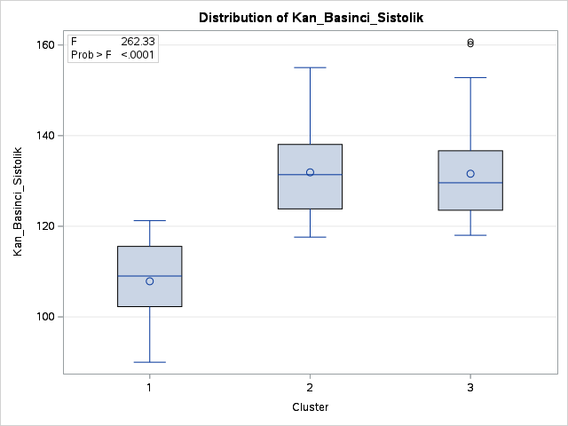

The GLM Procedure

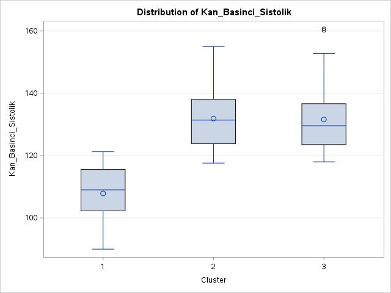

The GLM Procedure

Tukey's Studentized Range (HSD) Test for Kan_Basinci_Sistolik

Note:This test controls the Type I experimentwise error rate.

| Alpha | 0.05 |
| --- | --- |
| Error Degrees of Freedom | 297 |
| Error Mean Square | 81.53517 |
| Critical Value of Studentized Range | 3.33122 |

| Comparisons significant at the 0.05 level are indicated by ***. CLUSTER Comparison | Comparisons significant at the 0.05 level are indicated by ***. Difference Between Means | Comparisons significant at the 0.05 level are indicated by ***. Simultaneous 95% Confidence Limits | Comparisons significant at the 0.05 level are indicated by ***. Simultaneous 95% Confidence Limits | Comparisons significant at the 0.05 level are indicated by ***. |
| --- | --- | --- | --- | --- |
| 2 - 3 | 0.309 | -3.188 | 3.806 |  |
| 2 - 1 | 24.040 | 21.011 | 27.069 | *** |
| 3 - 2 | -0.309 | -3.806 | 3.188 |  |
| 3 - 1 | 23.731 | 20.730 | 26.733 | *** |
| 1 - 2 | -24.040 | -27.069 | -21.011 | *** |
| 1 - 3 | -23.731 | -26.733 | -20.730 | *** |

The GLM Procedure

| Class Level Information Class | Class Level Information Levels | Class Level Information Values |
| --- | --- | --- |
| CLUSTER | 3 | 1 2 3 |

| Number of Observations Read | 300 |
| --- | --- |
| Number of Observations Used | 300 |

The GLM Procedure

Dependent Variable: Kan_Basinci_Diyastolik Kan_Basinci_Diyastolik

| Source | DF | Sum of Squares | Mean Square | F Value | Pr > F |
| --- | --- | --- | --- | --- | --- |
| Model | 2 | 1262.62937 | 631.31469 | 7.81 | 0.0005 |
| Error | 297 | 24013.13187 | 80.85230 |  |  |
| Corrected Total | 299 | 25275.76124 |  |  |  |

| R-Square | Coeff Var | Root MSE | Kan_Basinci_Diyastolik Mean |
| --- | --- | --- | --- |
| 0.049954 | 11.31284 | 8.991790 | 79.48304 |

| Source | DF | Type I SS | Mean Square | F Value | Pr > F |
| --- | --- | --- | --- | --- | --- |
| CLUSTER | 2 | 1262.629371 | 631.314686 | 7.81 | 0.0005 |

| Source | DF | Type III SS | Mean Square | F Value | Pr > F |
| --- | --- | --- | --- | --- | --- |
| CLUSTER | 2 | 1262.629371 | 631.314686 | 7.81 | 0.0005 |

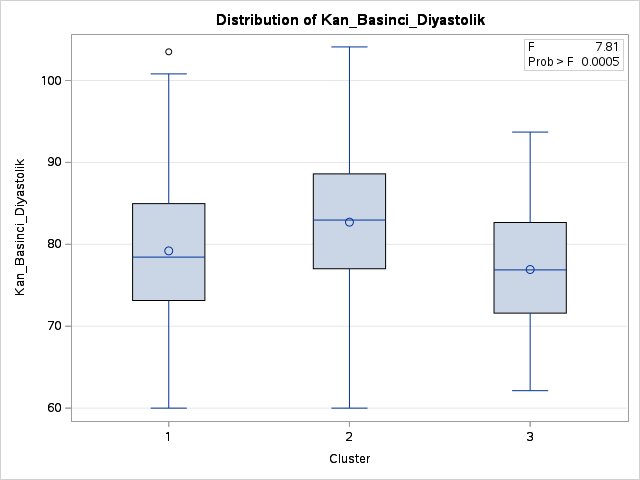

The GLM Procedure

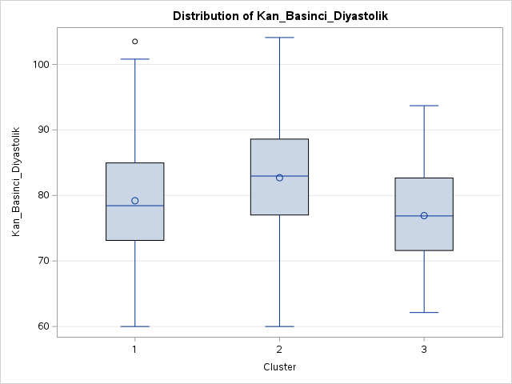

The GLM Procedure

Tukey's Studentized Range (HSD) Test for Kan_Basinci_Diyastolik

Note:This test controls the Type I experimentwise error rate.

| Alpha | 0.05 |
| --- | --- |
| Error Degrees of Freedom | 297 |
| Error Mean Square | 80.8523 |
| Critical Value of Studentized Range | 3.33122 |

| Comparisons significant at the 0.05 level are indicated by ***. CLUSTER Comparison | Comparisons significant at the 0.05 level are indicated by ***. Difference Between Means | Comparisons significant at the 0.05 level are indicated by ***. Simultaneous 95% Confidence Limits | Comparisons significant at the 0.05 level are indicated by ***. Simultaneous 95% Confidence Limits | Comparisons significant at the 0.05 level are indicated by ***. |
| --- | --- | --- | --- | --- |
| 2 - 1 | 3.508 | 0.492 | 6.525 | *** |
| 2 - 3 | 5.784 | 2.302 | 9.266 | *** |
| 1 - 2 | -3.508 | -6.525 | -0.492 | *** |
| 1 - 3 | 2.276 | -0.713 | 5.264 |  |
| 3 - 2 | -5.784 | -9.266 | -2.302 | *** |
| 3 - 1 | -2.276 | -5.264 | 0.713 |  |

The GLM Procedure

| Class Level Information Class | Class Level Information Levels | Class Level Information Values |
| --- | --- | --- |
| CLUSTER | 3 | 1 2 3 |

| Number of Observations Read | 300 |
| --- | --- |
| Number of Observations Used | 300 |

The GLM Procedure

Dependent Variable: Stress_Seviyesi_Biosensor Stress_Seviyesi_Biosensor

| Source | DF | Sum of Squares | Mean Square | F Value | Pr > F |
| --- | --- | --- | --- | --- | --- |
| Model | 2 | 5.477465 | 2.738733 | 0.42 | 0.6546 |
| Error | 297 | 1916.764568 | 6.453753 |  |  |
| Corrected Total | 299 | 1922.242033 |  |  |  |

| R-Square | Coeff Var | Root MSE | Stress_Seviyesi_Biosensor Mean |
| --- | --- | --- | --- |
| 0.002850 | 46.76239 | 2.540424 | 5.432621 |

| Source | DF | Type I SS | Mean Square | F Value | Pr > F |
| --- | --- | --- | --- | --- | --- |
| CLUSTER | 2 | 5.47746524 | 2.73873262 | 0.42 | 0.6546 |

| Source | DF | Type III SS | Mean Square | F Value | Pr > F |
| --- | --- | --- | --- | --- | --- |
| CLUSTER | 2 | 5.47746524 | 2.73873262 | 0.42 | 0.6546 |

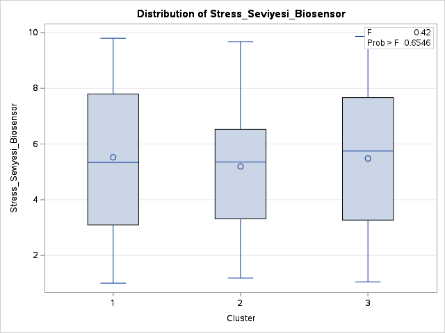

The GLM Procedure

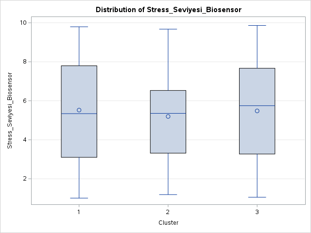

The GLM Procedure

Tukey's Studentized Range (HSD) Test for Stress_Seviyesi_Biosensor

Note:This test controls the Type I experimentwise error rate.

| Alpha | 0.05 |
| --- | --- |
| Error Degrees of Freedom | 297 |
| Error Mean Square | 6.453753 |
| Critical Value of Studentized Range | 3.33122 |

| Comparisons significant at the 0.05 level are indicated by ***. CLUSTER Comparison | Comparisons significant at the 0.05 level are indicated by ***. Difference Between Means | Comparisons significant at the 0.05 level are indicated by ***. Simultaneous 95% Confidence Limits | Comparisons significant at the 0.05 level are indicated by ***. Simultaneous 95% Confidence Limits | Comparisons significant at the 0.05 level are indicated by ***. |
| --- | --- | --- | --- | --- |
| 1 - 3 | 0.0429 | -0.8015 | 0.8874 |  |
| 1 - 2 | 0.3264 | -0.5257 | 1.1785 |  |
| 3 - 1 | -0.0429 | -0.8874 | 0.8015 |  |
| 3 - 2 | 0.2835 | -0.7004 | 1.2673 |  |
| 2 - 1 | -0.3264 | -1.1785 | 0.5257 |  |
| 2 - 3 | -0.2835 | -1.2673 | 0.7004 |  |

The GLM Procedure

| Class Level Information Class | Class Level Information Levels | Class Level Information Values |
| --- | --- | --- |
| CLUSTER | 3 | 1 2 3 |

| Number of Observations Read | 300 |
| --- | --- |
| Number of Observations Used | 300 |

The GLM Procedure

Dependent Variable: Stress_Seviyesi_Bildirim Stress_Seviyesi_Bildirim

| Source | DF | Sum of Squares | Mean Square | F Value | Pr > F |
| --- | --- | --- | --- | --- | --- |
| Model | 2 | 4.398014 | 2.199007 | 0.33 | 0.7181 |
| Error | 297 | 1970.455492 | 6.634530 |  |  |
| Corrected Total | 299 | 1974.853506 |  |  |  |

| R-Square | Coeff Var | Root MSE | Stress_Seviyesi_Bildirim Mean |
| --- | --- | --- | --- |
| 0.002227 | 47.00130 | 2.575758 | 5.480185 |

| Source | DF | Type I SS | Mean Square | F Value | Pr > F |
| --- | --- | --- | --- | --- | --- |
| CLUSTER | 2 | 4.39801351 | 2.19900675 | 0.33 | 0.7181 |

| Source | DF | Type III SS | Mean Square | F Value | Pr > F |
| --- | --- | --- | --- | --- | --- |
| CLUSTER | 2 | 4.39801351 | 2.19900675 | 0.33 | 0.7181 |

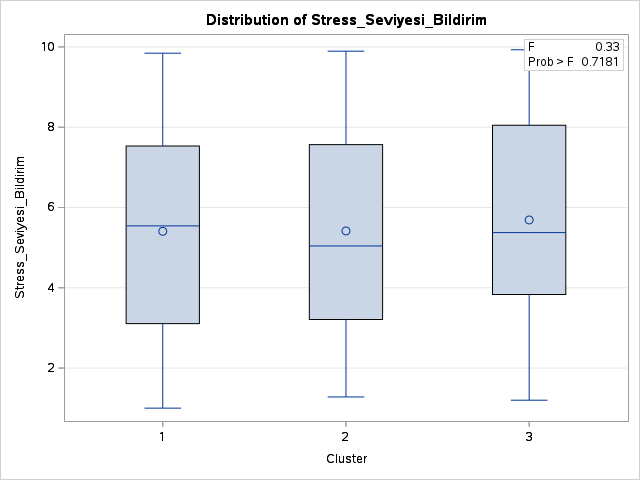

The GLM Procedure

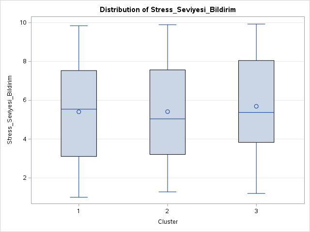

The GLM Procedure

Tukey's Studentized Range (HSD) Test for Stress_Seviyesi_Bildirim

Note:This test controls the Type I experimentwise error rate.

| Alpha | 0.05 |
| --- | --- |
| Error Degrees of Freedom | 297 |
| Error Mean Square | 6.63453 |
| Critical Value of Studentized Range | 3.33122 |

| Comparisons significant at the 0.05 level are indicated by ***. CLUSTER Comparison | Comparisons significant at the 0.05 level are indicated by ***. Difference Between Means | Comparisons significant at the 0.05 level are indicated by ***. Simultaneous 95% Confidence Limits | Comparisons significant at the 0.05 level are indicated by ***. Simultaneous 95% Confidence Limits | Comparisons significant at the 0.05 level are indicated by ***. |
| --- | --- | --- | --- | --- |
| 3 - 2 | 0.2735 | -0.7241 | 1.2710 |  |
| 3 - 1 | 0.2824 | -0.5738 | 1.1385 |  |
| 2 - 3 | -0.2735 | -1.2710 | 0.7241 |  |
| 2 - 1 | 0.0089 | -0.8550 | 0.8729 |  |
| 1 - 3 | -0.2824 | -1.1385 | 0.5738 |  |
| 1 - 2 | -0.0089 | -0.8729 | 0.8550 |  |

The GLM Procedure

| Class Level Information Class | Class Level Information Levels | Class Level Information Values |
| --- | --- | --- |
| CLUSTER | 3 | 1 2 3 |

| Number of Observations Read | 300 |
| --- | --- |
| Number of Observations Used | 300 |

The GLM Procedure

Dependent Variable: Ders_Saatleri Ders_Saatleri

| Source | DF | Sum of Squares | Mean Square | F Value | Pr > F |
| --- | --- | --- | --- | --- | --- |
| Model | 2 | 7798.56301 | 3899.28151 | 49.84 | <.0001 |
| Error | 297 | 23238.29719 | 78.24342 |  |  |
| Corrected Total | 299 | 31036.86020 |  |  |  |

| R-Square | Coeff Var | Root MSE | Ders_Saatleri Mean |
| --- | --- | --- | --- |
| 0.251268 | 29.81684 | 8.845531 | 29.66622 |

| Source | DF | Type I SS | Mean Square | F Value | Pr > F |
| --- | --- | --- | --- | --- | --- |
| CLUSTER | 2 | 7798.563014 | 3899.281507 | 49.84 | <.0001 |

| Source | DF | Type III SS | Mean Square | F Value | Pr > F |
| --- | --- | --- | --- | --- | --- |
| CLUSTER | 2 | 7798.563014 | 3899.281507 | 49.84 | <.0001 |

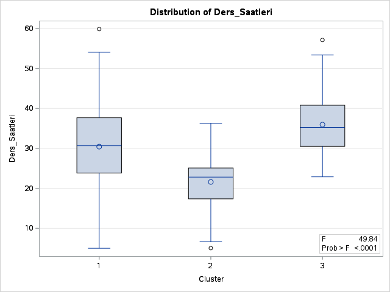

The GLM Procedure

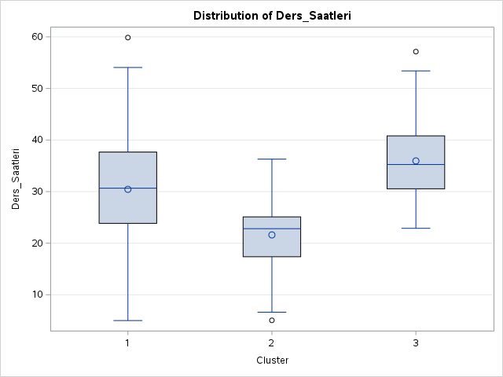

The GLM Procedure

Tukey's Studentized Range (HSD) Test for Ders_Saatleri

Note:This test controls the Type I experimentwise error rate.

| Alpha | 0.05 |
| --- | --- |
| Error Degrees of Freedom | 297 |
| Error Mean Square | 78.24342 |
| Critical Value of Studentized Range | 3.33122 |

| Comparisons significant at the 0.05 level are indicated by ***. CLUSTER Comparison | Comparisons significant at the 0.05 level are indicated by ***. Difference Between Means | Comparisons significant at the 0.05 level are indicated by ***. Simultaneous 95% Confidence Limits | Comparisons significant at the 0.05 level are indicated by ***. Simultaneous 95% Confidence Limits | Comparisons significant at the 0.05 level are indicated by ***. |
| --- | --- | --- | --- | --- |
| 3 - 1 | 5.510 | 2.570 | 8.450 | *** |
| 3 - 2 | 14.347 | 10.921 | 17.773 | *** |
| 1 - 3 | -5.510 | -8.450 | -2.570 | *** |
| 1 - 2 | 8.837 | 5.870 | 11.804 | *** |
| 2 - 3 | -14.347 | -17.773 | -10.921 | *** |
| 2 - 1 | -8.837 | -11.804 | -5.870 | *** |

The GLM Procedure

| Class Level Information Class | Class Level Information Levels | Class Level Information Values |
| --- | --- | --- |
| CLUSTER | 3 | 1 2 3 |

| Number of Observations Read | 300 |
| --- | --- |
| Number of Observations Used | 300 |

The GLM Procedure

Dependent Variable: Proje_Saatleri Proje_Saatleri

| Source | DF | Sum of Squares | Mean Square | F Value | Pr > F |
| --- | --- | --- | --- | --- | --- |
| Model | 2 | 110.517383 | 55.258692 | 2.09 | 0.1256 |
| Error | 297 | 7854.851333 | 26.447311 |  |  |
| Corrected Total | 299 | 7965.368716 |  |  |  |

| R-Square | Coeff Var | Root MSE | Proje_Saatleri Mean |
| --- | --- | --- | --- |
| 0.013875 | 34.46023 | 5.142695 | 14.92356 |

| Source | DF | Type I SS | Mean Square | F Value | Pr > F |
| --- | --- | --- | --- | --- | --- |
| CLUSTER | 2 | 110.5173835 | 55.2586917 | 2.09 | 0.1256 |

| Source | DF | Type III SS | Mean Square | F Value | Pr > F |
| --- | --- | --- | --- | --- | --- |
| CLUSTER | 2 | 110.5173835 | 55.2586917 | 2.09 | 0.1256 |

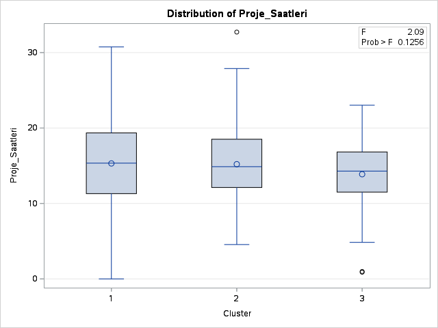

The GLM Procedure

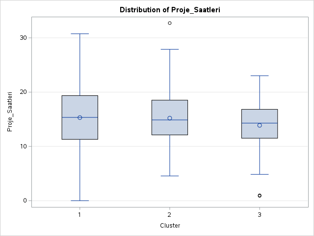

The GLM Procedure

Tukey's Studentized Range (HSD) Test for Proje_Saatleri

Note:This test controls the Type I experimentwise error rate.

| Alpha | 0.05 |
| --- | --- |
| Error Degrees of Freedom | 297 |
| Error Mean Square | 26.44731 |
| Critical Value of Studentized Range | 3.33122 |

| Comparisons significant at the 0.05 level are indicated by ***. CLUSTER Comparison | Comparisons significant at the 0.05 level are indicated by ***. Difference Between Means | Comparisons significant at the 0.05 level are indicated by ***. Simultaneous 95% Confidence Limits | Comparisons significant at the 0.05 level are indicated by ***. Simultaneous 95% Confidence Limits | Comparisons significant at the 0.05 level are indicated by ***. |
| --- | --- | --- | --- | --- |
| 1 - 2 | 0.0996 | -1.6254 | 1.8246 |  |
| 1 - 3 | 1.4309 | -0.2785 | 3.1403 |  |
| 2 - 1 | -0.0996 | -1.8246 | 1.6254 |  |
| 2 - 3 | 1.3313 | -0.6604 | 3.3230 |  |
| 3 - 1 | -1.4309 | -3.1403 | 0.2785 |  |
| 3 - 2 | -1.3313 | -3.3230 | 0.6604 |  |

The GLM Procedure

| Class Level Information Class | Class Level Information Levels | Class Level Information Values |
| --- | --- | --- |
| CLUSTER | 3 | 1 2 3 |

| Number of Observations Read | 300 |
| --- | --- |
| Number of Observations Used | 300 |

The GLM Procedure

Dependent Variable: Yas Yas

| Source | DF | Sum of Squares | Mean Square | F Value | Pr > F |
| --- | --- | --- | --- | --- | --- |
| Model | 2 | 29.577980 | 14.788990 | 3.71 | 0.0256 |
| Error | 297 | 1183.942020 | 3.986337 |  |  |
| Corrected Total | 299 | 1213.520000 |  |  |  |

| R-Square | Coeff Var | Root MSE | Yas Mean |
| --- | --- | --- | --- |
| 0.024374 | 9.489455 | 1.996581 | 21.04000 |

| Source | DF | Type I SS | Mean Square | F Value | Pr > F |
| --- | --- | --- | --- | --- | --- |
| CLUSTER | 2 | 29.57798005 | 14.78899003 | 3.71 | 0.0256 |

| Source | DF | Type III SS | Mean Square | F Value | Pr > F |
| --- | --- | --- | --- | --- | --- |
| CLUSTER | 2 | 29.57798005 | 14.78899003 | 3.71 | 0.0256 |

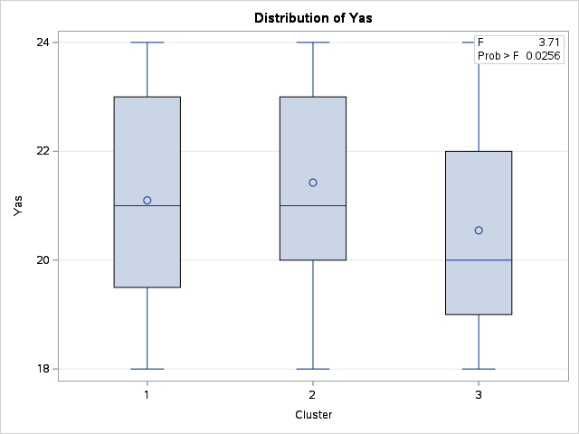

The GLM Procedure

Dependent Variable: Nabiz Nabiz

| Source | DF | Sum of Squares | Mean Square | F Value | Pr > F |
| --- | --- | --- | --- | --- | --- |
| Model | 2 | 2617.66442 | 1308.83221 | 16.53 | <.0001 |
| Error | 297 | 23521.27182 | 79.19620 |  |  |
| Corrected Total | 299 | 26138.93624 |  |  |  |

| R-Square | Coeff Var | Root MSE | Nabiz Mean |
| --- | --- | --- | --- |
| 0.100144 | 12.64262 | 8.899225 | 70.39066 |

| Source | DF | Type I SS | Mean Square | F Value | Pr > F |
| --- | --- | --- | --- | --- | --- |
| CLUSTER | 2 | 2617.664421 | 1308.832210 | 16.53 | <.0001 |

| Source | DF | Type III SS | Mean Square | F Value | Pr > F |
| --- | --- | --- | --- | --- | --- |
| CLUSTER | 2 | 2617.664421 | 1308.832210 | 16.53 | <.0001 |

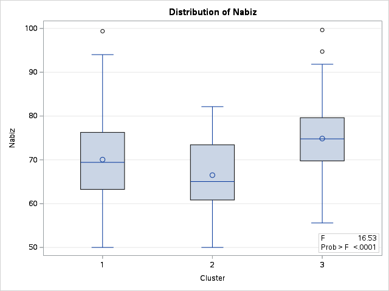

The GLM Procedure

Dependent Variable: Kan_Basinci_Sistolik Kan_Basinci_Sistolik

| Source | DF | Sum of Squares | Mean Square | F Value | Pr > F |
| --- | --- | --- | --- | --- | --- |
| Model | 2 | 42777.47511 | 21388.73755 | 262.33 | <.0001 |
| Error | 297 | 24215.94475 | 81.53517 |  |  |
| Corrected Total | 299 | 66993.41986 |  |  |  |

| R-Square | Coeff Var | Root MSE | Kan_Basinci_Sistolik Mean |
| --- | --- | --- | --- |
| 0.638532 | 7.547179 | 9.029683 | 119.6431 |

| Source | DF | Type I SS | Mean Square | F Value | Pr > F |
| --- | --- | --- | --- | --- | --- |
| CLUSTER | 2 | 42777.47511 | 21388.73755 | 262.33 | <.0001 |

| Source | DF | Type III SS | Mean Square | F Value | Pr > F |
| --- | --- | --- | --- | --- | --- |
| CLUSTER | 2 | 42777.47511 | 21388.73755 | 262.33 | <.0001 |

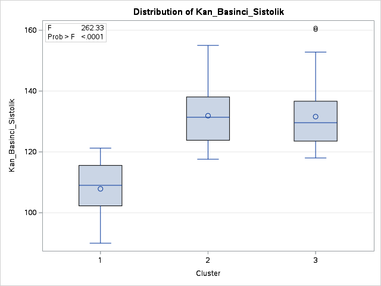

The GLM Procedure

Dependent Variable: Kan_Basinci_Diyastolik Kan_Basinci_Diyastolik

| Source | DF | Sum of Squares | Mean Square | F Value | Pr > F |
| --- | --- | --- | --- | --- | --- |
| Model | 2 | 1262.62937 | 631.31469 | 7.81 | 0.0005 |
| Error | 297 | 24013.13187 | 80.85230 |  |  |
| Corrected Total | 299 | 25275.76124 |  |  |  |

| R-Square | Coeff Var | Root MSE | Kan_Basinci_Diyastolik Mean |
| --- | --- | --- | --- |
| 0.049954 | 11.31284 | 8.991790 | 79.48304 |

| Source | DF | Type I SS | Mean Square | F Value | Pr > F |
| --- | --- | --- | --- | --- | --- |
| CLUSTER | 2 | 1262.629371 | 631.314686 | 7.81 | 0.0005 |

| Source | DF | Type III SS | Mean Square | F Value | Pr > F |
| --- | --- | --- | --- | --- | --- |
| CLUSTER | 2 | 1262.629371 | 631.314686 | 7.81 | 0.0005 |

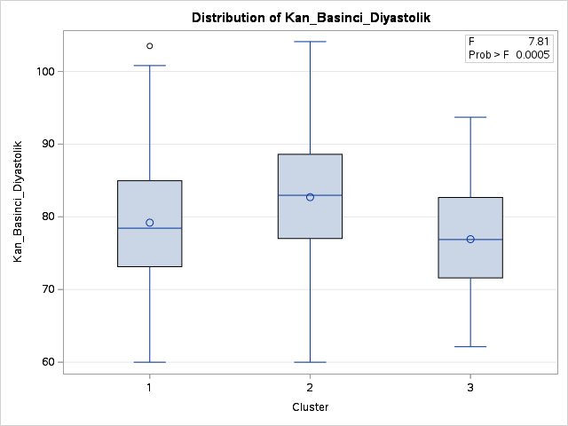

The GLM Procedure

Dependent Variable: Stress_Seviyesi_Biosensor Stress_Seviyesi_Biosensor

| Source | DF | Sum of Squares | Mean Square | F Value | Pr > F |
| --- | --- | --- | --- | --- | --- |
| Model | 2 | 5.477465 | 2.738733 | 0.42 | 0.6546 |
| Error | 297 | 1916.764568 | 6.453753 |  |  |
| Corrected Total | 299 | 1922.242033 |  |  |  |

| R-Square | Coeff Var | Root MSE | Stress_Seviyesi_Biosensor Mean |
| --- | --- | --- | --- |
| 0.002850 | 46.76239 | 2.540424 | 5.432621 |

| Source | DF | Type I SS | Mean Square | F Value | Pr > F |
| --- | --- | --- | --- | --- | --- |
| CLUSTER | 2 | 5.47746524 | 2.73873262 | 0.42 | 0.6546 |

| Source | DF | Type III SS | Mean Square | F Value | Pr > F |
| --- | --- | --- | --- | --- | --- |
| CLUSTER | 2 | 5.47746524 | 2.73873262 | 0.42 | 0.6546 |

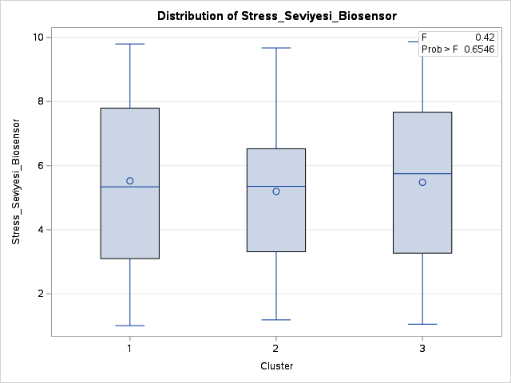

The GLM Procedure

Dependent Variable: Stress_Seviyesi_Bildirim Stress_Seviyesi_Bildirim

| Source | DF | Sum of Squares | Mean Square | F Value | Pr > F |
| --- | --- | --- | --- | --- | --- |
| Model | 2 | 4.398014 | 2.199007 | 0.33 | 0.7181 |
| Error | 297 | 1970.455492 | 6.634530 |  |  |
| Corrected Total | 299 | 1974.853506 |  |  |  |

| R-Square | Coeff Var | Root MSE | Stress_Seviyesi_Bildirim Mean |
| --- | --- | --- | --- |
| 0.002227 | 47.00130 | 2.575758 | 5.480185 |

| Source | DF | Type I SS | Mean Square | F Value | Pr > F |
| --- | --- | --- | --- | --- | --- |
| CLUSTER | 2 | 4.39801351 | 2.19900675 | 0.33 | 0.7181 |

| Source | DF | Type III SS | Mean Square | F Value | Pr > F |
| --- | --- | --- | --- | --- | --- |
| CLUSTER | 2 | 4.39801351 | 2.19900675 | 0.33 | 0.7181 |

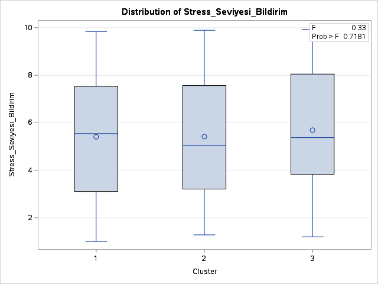

The GLM Procedure

Dependent Variable: Ders_Saatleri Ders_Saatleri

| Source | DF | Sum of Squares | Mean Square | F Value | Pr > F |
| --- | --- | --- | --- | --- | --- |
| Model | 2 | 7798.56301 | 3899.28151 | 49.84 | <.0001 |
| Error | 297 | 23238.29719 | 78.24342 |  |  |
| Corrected Total | 299 | 31036.86020 |  |  |  |

| R-Square | Coeff Var | Root MSE | Ders_Saatleri Mean |
| --- | --- | --- | --- |
| 0.251268 | 29.81684 | 8.845531 | 29.66622 |

| Source | DF | Type I SS | Mean Square | F Value | Pr > F |
| --- | --- | --- | --- | --- | --- |
| CLUSTER | 2 | 7798.563014 | 3899.281507 | 49.84 | <.0001 |

| Source | DF | Type III SS | Mean Square | F Value | Pr > F |
| --- | --- | --- | --- | --- | --- |
| CLUSTER | 2 | 7798.563014 | 3899.281507 | 49.84 | <.0001 |

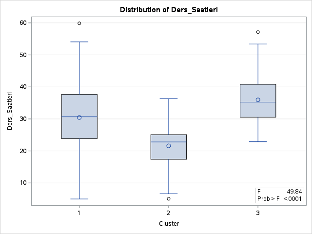

The GLM Procedure

Dependent Variable: Proje_Saatleri Proje_Saatleri

| Source | DF | Sum of Squares | Mean Square | F Value | Pr > F |
| --- | --- | --- | --- | --- | --- |
| Model | 2 | 110.517383 | 55.258692 | 2.09 | 0.1256 |
| Error | 297 | 7854.851333 | 26.447311 |  |  |
| Corrected Total | 299 | 7965.368716 |  |  |  |

| R-Square | Coeff Var | Root MSE | Proje_Saatleri Mean |
| --- | --- | --- | --- |
| 0.013875 | 34.46023 | 5.142695 | 14.92356 |

| Source | DF | Type I SS | Mean Square | F Value | Pr > F |
| --- | --- | --- | --- | --- | --- |
| CLUSTER | 2 | 110.5173835 | 55.2586917 | 2.09 | 0.1256 |

| Source | DF | Type III SS | Mean Square | F Value | Pr > F |
| --- | --- | --- | --- | --- | --- |
| CLUSTER | 2 | 110.5173835 | 55.2586917 | 2.09 | 0.1256 |

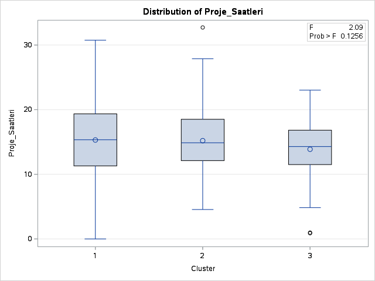

The GLM Procedure

Multivariate Analysis of Variance

| E = Error SSCP Matrix | E = Error SSCP Matrix Yas | E = Error SSCP Matrix Nabiz | E = Error SSCP Matrix Kan_Basinci_Sistolik | E = Error SSCP Matrix Kan_Basinci_Diyastolik | E = Error SSCP Matrix Stress_Seviyesi_Biosensor | E = Error SSCP Matrix Stress_Seviyesi_Bildirim | E = Error SSCP Matrix Ders_Saatleri | E = Error SSCP Matrix Proje_Saatleri |
| --- | --- | --- | --- | --- | --- | --- | --- | --- |
| Yas | 1183.9420199 | -216.3217725 | -350.8395213 | 491.61070137 | 36.127352206 | 19.124896351 | -237.4874955 | -318.0423269 |
| Nabiz | -216.3217725 | 23521.27182 | -2565.421198 | -761.6216792 | 1220.9554806 | -54.69264969 | -3865.390996 | 392.93218357 |
| Kan_Basinci_Sistolik | -350.8395213 | -2565.421198 | 24215.94475 | -83.71929532 | -534.4127509 | -601.9576416 | 3335.2382254 | -187.0007278 |
| Kan_Basinci_Diyastolik | 491.61070137 | -761.6216792 | -83.71929532 | 24013.131869 | -467.2977765 | 74.350132209 | 1453.9693156 | -123.6189 |
| Stress_Seviyesi_Biosensor | 36.127352206 | 1220.9554806 | -534.4127509 | -467.2977765 | 1916.7645678 | -84.58442095 | -1422.354438 | 297.23145112 |
| Stress_Seviyesi_Bildirim | 19.124896351 | -54.69264969 | -601.9576416 | 74.350132209 | -84.58442095 | 1970.4554924 | 531.97516274 | -159.3625131 |
| Ders_Saatleri | -237.4874955 | -3865.390996 | 3335.2382254 | 1453.9693156 | -1422.354438 | 531.97516274 | 23238.297185 | 505.98720143 |
| Proje_Saatleri | -318.0423269 | 392.93218357 | -187.0007278 | -123.6189 | 297.23145112 | -159.3625131 | 505.98720143 | 7854.8513328 |

| Partial Correlation Coefficients from the Error SSCP Matrix / Prob > \|r\| DF = 297 | Partial Correlation Coefficients from the Error SSCP Matrix / Prob > \|r\| Yas | Partial Correlation Coefficients from the Error SSCP Matrix / Prob > \|r\| Nabiz | Partial Correlation Coefficients from the Error SSCP Matrix / Prob > \|r\| Kan_Basinci_Sistolik | Partial Correlation Coefficients from the Error SSCP Matrix / Prob > \|r\| Kan_Basinci_Diyastolik | Partial Correlation Coefficients from the Error SSCP Matrix / Prob > \|r\| Stress_Seviyesi_Biosensor | Partial Correlation Coefficients from the Error SSCP Matrix / Prob > \|r\| Stress_Seviyesi_Bildirim | Partial Correlation Coefficients from the Error SSCP Matrix / Prob > \|r\| Ders_Saatleri | Partial Correlation Coefficients from the Error SSCP Matrix / Prob > \|r\| Proje_Saatleri |
| --- | --- | --- | --- | --- | --- | --- | --- | --- |
| Yas | 1.000000 | -0.040993 0.4808 | -0.065523 0.2595 | 0.092200 0.1122 | 0.023982 0.6801 | 0.012521 0.8296 | -0.045277 0.4362 | -0.104292 0.0722 |
| Nabiz | -0.040993 0.4808 | 1.000000 | -0.107492 0.0639 | -0.032047 0.5816 | 0.181838 0.0016 | -0.008034 0.8902 | -0.165334 0.0042 | 0.028908 0.6192 |
| Kan_Basinci_Sistolik | -0.065523 0.2595 | -0.107492 0.0639 | 1.000000 | -0.003472 0.9524 | -0.078441 0.1769 | -0.087143 0.1334 | 0.140596 0.0151 | -0.013559 0.8157 |
| Kan_Basinci_Diyastolik | 0.092200 0.1122 | -0.032047 0.5816 | -0.003472 0.9524 | 1.000000 | -0.068879 0.2358 | 0.010809 0.8526 | 0.061550 0.2896 | -0.009001 0.8770 |
| Stress_Seviyesi_Biosensor | 0.023982 0.6801 | 0.181838 0.0016 | -0.078441 0.1769 | -0.068879 0.2358 | 1.000000 | -0.043523 0.4541 | -0.213119 0.0002 | 0.076602 0.1873 |
| Stress_Seviyesi_Bildirim | 0.012521 0.8296 | -0.008034 0.8902 | -0.087143 0.1334 | 0.010809 0.8526 | -0.043523 0.4541 | 1.000000 | 0.078615 0.1759 | -0.040507 0.4860 |
| Ders_Saatleri | -0.045277 0.4362 | -0.165334 0.0042 | 0.140596 0.0151 | 0.061550 0.2896 | -0.213119 0.0002 | 0.078615 0.1759 | 1.000000 | 0.037451 0.5196 |
| Proje_Saatleri | -0.104292 0.0722 | 0.028908 0.6192 | -0.013559 0.8157 | -0.009001 0.8770 | 0.076602 0.1873 | -0.040507 0.4860 | 0.037451 0.5196 | 1.000000 |

The GLM Procedure

Multivariate Analysis of Variance

| H = Type III SSCP Matrix for CLUSTER | H = Type III SSCP Matrix for CLUSTER Yas | H = Type III SSCP Matrix for CLUSTER Nabiz | H = Type III SSCP Matrix for CLUSTER Kan_Basinci_Sistolik | H = Type III SSCP Matrix for CLUSTER Kan_Basinci_Diyastolik | H = Type III SSCP Matrix for CLUSTER Stress_Seviyesi_Biosensor | H = Type III SSCP Matrix for CLUSTER Stress_Seviyesi_Bildirim | H = Type III SSCP Matrix for CLUSTER Ders_Saatleri | H = Type III SSCP Matrix for CLUSTER Proje_Saatleri |
| --- | --- | --- | --- | --- | --- | --- | --- | --- |
| Yas | 29.577980053 | -277.4925432 | -203.0176916 | 182.71556492 | -7.576730346 | -10.19771698 | -452.0131234 | 50.14626476 |
| Nabiz | -277.4925432 | 2617.6644206 | 1135.2411224 | -1757.956495 | 78.19557108 | 92.119936404 | 4353.5523737 | -451.3594669 |
| Kan_Basinci_Sistolik | -203.0176916 | 1135.2411224 | 42777.47511 | 1100.0406413 | -330.5632998 | 261.0582614 | -2969.320338 | -1371.464915 |
| Kan_Basinci_Diyastolik | 182.71556492 | -1757.956495 | 1100.0406413 | 1262.6293711 | -68.56739 | -52.12677405 | -3137.677108 | 251.33727369 |
| Stress_Seviyesi_Biosensor | -7.576730346 | 78.19557108 | -330.5632998 | -68.56739 | 5.4774652399 | 0.8460038129 | 171.91860877 | -3.349070238 |
| Stress_Seviyesi_Bildirim | -10.19771698 | 92.119936404 | 261.0582614 | -52.12677405 | 0.8460038129 | 4.398013506 | 127.80961139 | -22.03186238 |
| Ders_Saatleri | -452.0131234 | 4353.5523737 | -2969.320338 | -3137.677108 | 171.91860877 | 127.80961139 | 7798.5630141 | -615.618406 |
| Proje_Saatleri | 50.14626476 | -451.3594669 | -1371.464915 | 251.33727369 | -3.349070238 | -22.03186238 | -615.618406 | 110.51738348 |

| Characteristic Roots and Vectors of: E Inverse * H, where H = Type III SSCP Matrix for CLUSTER E = Error SSCP Matrix Characteristic Root | Characteristic Roots and Vectors of: E Inverse * H, where H = Type III SSCP Matrix for CLUSTER E = Error SSCP Matrix Percent | Characteristic Roots and Vectors of: E Inverse * H, where H = Type III SSCP Matrix for CLUSTER E = Error SSCP Matrix Characteristic Vector V'EV=1 Yas | Characteristic Roots and Vectors of: E Inverse * H, where H = Type III SSCP Matrix for CLUSTER E = Error SSCP Matrix Characteristic Vector V'EV=1 Nabiz | Characteristic Roots and Vectors of: E Inverse * H, where H = Type III SSCP Matrix for CLUSTER E = Error SSCP Matrix Characteristic Vector V'EV=1 Kan_Basinci_Sistolik | Characteristic Roots and Vectors of: E Inverse * H, where H = Type III SSCP Matrix for CLUSTER E = Error SSCP Matrix Characteristic Vector V'EV=1 Kan_Basinci_Diyastolik | Characteristic Roots and Vectors of: E Inverse * H, where H = Type III SSCP Matrix for CLUSTER E = Error SSCP Matrix Characteristic Vector V'EV=1 Stress_Seviyesi_Biosensor | Characteristic Roots and Vectors of: E Inverse * H, where H = Type III SSCP Matrix for CLUSTER E = Error SSCP Matrix Characteristic Vector V'EV=1 Stress_Seviyesi_Bildirim | Characteristic Roots and Vectors of: E Inverse * H, where H = Type III SSCP Matrix for CLUSTER E = Error SSCP Matrix Characteristic Vector V'EV=1 Ders_Saatleri | Characteristic Roots and Vectors of: E Inverse * H, where H = Type III SSCP Matrix for CLUSTER E = Error SSCP Matrix Characteristic Vector V'EV=1 Proje_Saatleri |
| --- | --- | --- | --- | --- | --- | --- | --- | --- | --- |
| 1.91441629 | 75.94 | 0.00116187 | 0.00050450 | 0.00650627 | 0.00035871 | -0.00015686 | 0.00279788 | -0.00162723 | -0.00018762 |
| 0.60640873 | 24.06 | -0.00382152 | 0.00355446 | 0.00062385 | -0.00193932 | 0.00300743 | 0.00001544 | 0.00553679 | -0.00224728 |
| 0.00000000 | 0.00 | -0.00124424 | -0.00102338 | 0.00020500 | 0.00033697 | 0.02343610 | -0.00003238 | 0.00019136 | -0.00006771 |
| 0.00000000 | 0.00 | -0.00000217 | -0.00028893 | -0.00013734 | 0.00008420 | 0.00091230 | 0.02253011 | -0.00023665 | 0.00012605 |
| 0.00000000 | 0.00 | 0.00237280 | 0.00061066 | 0.00039682 | -0.00040721 | -0.00128145 | 0.00077700 | 0.00068229 | 0.01118428 |
| 0.00000000 | 0.00 | 0.02901915 | 0.00076067 | 0.00021707 | -0.00041245 | 0.00078297 | -0.00035711 | 0.00116264 | 0.00000000 |
| 0.00000000 | 0.00 | -0.00204095 | 0.00148084 | -0.00009394 | 0.00616069 | 0.00099898 | -0.00045563 | 0.00148339 | 0.00000000 |
| 0.00000000 | 0.00 | 0.00036149 | 0.00529434 | -0.00037278 | -0.00019983 | -0.00210538 | 0.00096026 | -0.00312628 | 0.00000000 |

| MANOVA Test Criteria and F Approximations for the Hypothesis of No Overall CLUSTER Effect H = Type III SSCP Matrix for CLUSTER E = Error SSCP Matrix S=2 M=2.5 N=144 Statistic | MANOVA Test Criteria and F Approximations for the Hypothesis of No Overall CLUSTER Effect H = Type III SSCP Matrix for CLUSTER E = Error SSCP Matrix S=2 M=2.5 N=144 Value | MANOVA Test Criteria and F Approximations for the Hypothesis of No Overall CLUSTER Effect H = Type III SSCP Matrix for CLUSTER E = Error SSCP Matrix S=2 M=2.5 N=144 F Value | MANOVA Test Criteria and F Approximations for the Hypothesis of No Overall CLUSTER Effect H = Type III SSCP Matrix for CLUSTER E = Error SSCP Matrix S=2 M=2.5 N=144 Num DF | MANOVA Test Criteria and F Approximations for the Hypothesis of No Overall CLUSTER Effect H = Type III SSCP Matrix for CLUSTER E = Error SSCP Matrix S=2 M=2.5 N=144 Den DF | MANOVA Test Criteria and F Approximations for the Hypothesis of No Overall CLUSTER Effect H = Type III SSCP Matrix for CLUSTER E = Error SSCP Matrix S=2 M=2.5 N=144 Pr > F |
| --- | --- | --- | --- | --- | --- |
| Wilks' Lambda | 0.21359563 | 42.19 | 16 | 580 | <.0001 |
| Pillai's Trace | 1.03437154 | 38.96 | 16 | 582 | <.0001 |
| Hotelling-Lawley Trace | 2.52082502 | 45.57 | 16 | 470.97 | <.0001 |
| Roy's Greatest Root | 1.91441629 | 69.64 | 8 | 291 | <.0001 |

NOTE: F Statistic for Roy's Greatest Root is an upper bound.  
NOTE: F Statistic for Wilks' Lambda is exact.

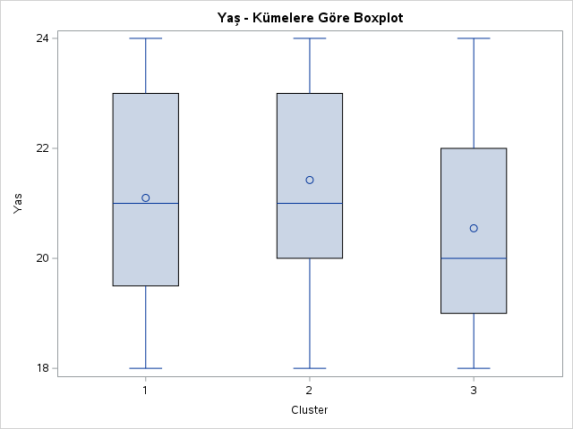

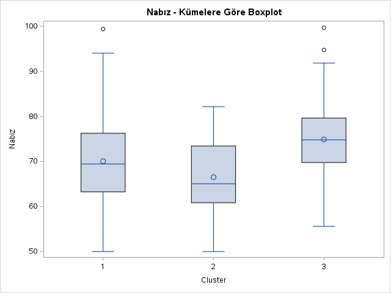

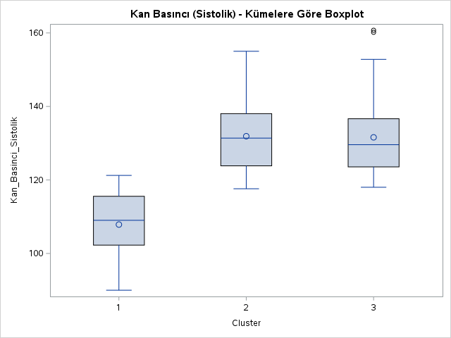

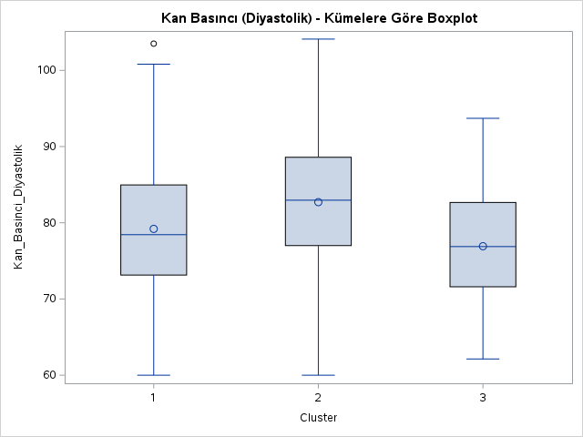

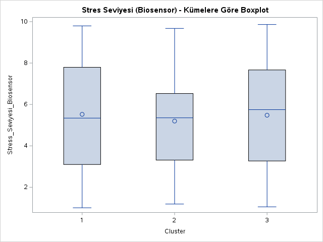

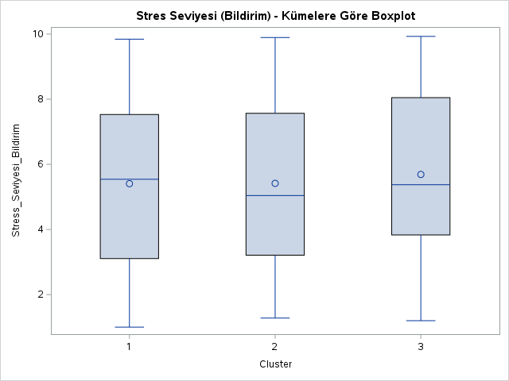

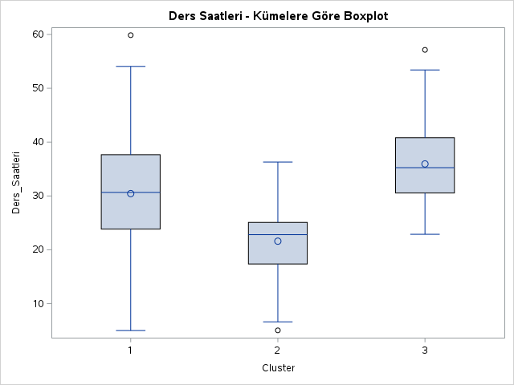

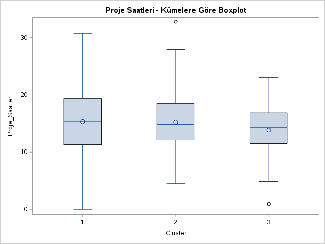

[figure not shown]

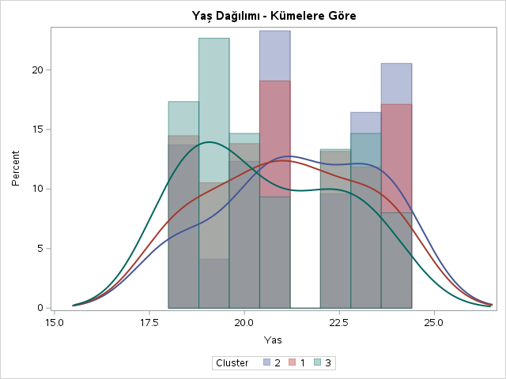

Yaş Dağılımı - Kümelere Göre

[output not shown]

The FREQ Procedure

| Frequency Percent Row Pct Col Pct |
| --- |

| Table of CLUSTER by Cinsiyet CLUSTER(Cluster) | Table of CLUSTER by Cinsiyet Cinsiyet(Cinsiyet) 0 | Table of CLUSTER by Cinsiyet Cinsiyet(Cinsiyet) 1 | Table of CLUSTER by Cinsiyet Cinsiyet(Cinsiyet) Total |
| --- | --- | --- | --- |
| 1 | 69 23.00 45.39 46.62 | 83 27.67 54.61 54.61 | 152 50.67 |
| 2 | 40 13.33 54.79 27.03 | 33 11.00 45.21 21.71 | 73 24.33 |
| 3 | 39 13.00 52.00 26.35 | 36 12.00 48.00 23.68 | 75 25.00 |
| Total | 148 49.33 | 152 50.67 | 300 100.00 |

Statistics for Table of CLUSTER by Cinsiyet

| Statistic | DF | Value | Prob |
| --- | --- | --- | --- |
| Chi-Square | 2 | 2.0277 | 0.3628 |
| Likelihood Ratio Chi-Square | 2 | 2.0303 | 0.3624 |
| Mantel-Haenszel Chi-Square | 1 | 1.2273 | 0.2679 |
| Phi Coefficient |  | 0.0822 |  |
| Contingency Coefficient |  | 0.0819 |  |
| Cramer's V |  | 0.0822 |  |

Sample Size = 300

| Frequency Percent Row Pct Col Pct |
| --- |

| Table of CLUSTER by Saglik_Riski_Seviyesi CLUSTER(Cluster) | Table of CLUSTER by Saglik_Riski_Seviyesi Saglik_Riski_Seviyesi(Saglik_Riski_Seviyesi) 1 | Table of CLUSTER by Saglik_Riski_Seviyesi Saglik_Riski_Seviyesi(Saglik_Riski_Seviyesi) 2 | Table of CLUSTER by Saglik_Riski_Seviyesi Saglik_Riski_Seviyesi(Saglik_Riski_Seviyesi) 3 | Table of CLUSTER by Saglik_Riski_Seviyesi Saglik_Riski_Seviyesi(Saglik_Riski_Seviyesi) Total |
| --- | --- | --- | --- | --- |
| 1 | 28 9.33 18.42 52.83 | 106 35.33 69.74 51.21 | 18 6.00 11.84 45.00 | 152 50.67 |
| 2 | 14 4.67 19.18 26.42 | 48 16.00 65.75 23.19 | 11 3.67 15.07 27.50 | 73 24.33 |
| 3 | 11 3.67 14.67 20.75 | 53 17.67 70.67 25.60 | 11 3.67 14.67 27.50 | 75 25.00 |
| Total | 53 17.67 | 207 69.00 | 40 13.33 | 300 100.00 |

Statistics for Table of CLUSTER by Saglik_Riski_Seviyesi

| Statistic | DF | Value | Prob |
| --- | --- | --- | --- |
| Chi-Square | 4 | 1.1974 | 0.8785 |
| Likelihood Ratio Chi-Square | 4 | 1.2195 | 0.8749 |
| Mantel-Haenszel Chi-Square | 1 | 0.6930 | 0.4051 |
| Phi Coefficient |  | 0.0632 |  |
| Contingency Coefficient |  | 0.0631 |  |
| Cramer's V |  | 0.0447 |  |

Sample Size = 300

The DISCRIM Procedure

| Total Sample Size | 300 | DF Total | 299 |
| --- | --- | --- | --- |
| Variables | 8 | DF Within Classes | 297 |
| Classes | 3 | DF Between Classes | 2 |

| Number of Observations Read | 300 |
| --- | --- |
| Number of Observations Used | 300 |

| Class Level Information CLUSTER | Class Level Information Variable Name | Class Level Information Frequency | Class Level Information Weight | Class Level Information Proportion | Class Level Information Prior Probability |
| --- | --- | --- | --- | --- | --- |
| 1 | 1 | 152 | 152.0000 | 0.506667 | 0.333333 |
| 2 | 2 | 73 | 73.0000 | 0.243333 | 0.333333 |
| 3 | 3 | 75 | 75.0000 | 0.250000 | 0.333333 |

| Pooled Covariance Matrix Information Covariance Matrix Rank | Pooled Covariance Matrix Information Natural Log of the Determinant of the Covariance Matrix |
| --- | --- |
| 8 | 25.74858 |

The DISCRIM Procedure

| Generalized Squared Distance to CLUSTER From CLUSTER | Generalized Squared Distance to CLUSTER 1 | Generalized Squared Distance to CLUSTER 2 | Generalized Squared Distance to CLUSTER 3 |
| --- | --- | --- | --- |
| 1 | 0 | 9.56717 | 7.99927 |
| 2 | 9.56717 | 0 | 4.97837 |
| 3 | 7.99927 | 4.97837 | 0 |

| Linear Discriminant Function for CLUSTER Variable | Linear Discriminant Function for CLUSTER Label | Linear Discriminant Function for CLUSTER 1 | Linear Discriminant Function for CLUSTER 2 | Linear Discriminant Function for CLUSTER 3 |
| --- | --- | --- | --- | --- |
| Constant |  | -236.96442 | -276.04649 | -278.87721 |
| Yas | Yas | 5.81998 | 5.94171 | 5.78913 |
| Nabiz | Nabiz | 1.13990 | 1.10705 | 1.23802 |
| Kan_Basinci_Sistolik | Kan_Basinci_Sistolik | 1.53585 | 1.85551 | 1.83416 |
| Kan_Basinci_Diyastolik | Kan_Basinci_Diyastolik | 0.89672 | 0.94678 | 0.87095 |
| Stress_Seviyesi_Biosensor | Stress_Seviyesi_Biosensor | 0.87526 | 0.81787 | 0.93271 |
| Stress_Seviyesi_Bildirim | Stress_Seviyesi_Bildirim | 1.22593 | 1.36755 | 1.34880 |
| Ders_Saatleri | Ders_Saatleri | 0.37019 | 0.19667 | 0.41735 |
| Proje_Saatleri | Proje_Saatleri | 0.77593 | 0.80335 | 0.71964 |

The DISCRIM Procedure

Classification Summary for Calibration Data: WORK.CLUST

Resubstitution Summary using Linear Discriminant Function

| Number of Observations and Percent Classified into CLUSTER From CLUSTER | Number of Observations and Percent Classified into CLUSTER 1 | Number of Observations and Percent Classified into CLUSTER 2 | Number of Observations and Percent Classified into CLUSTER 3 | Number of Observations and Percent Classified into CLUSTER Total |
| --- | --- | --- | --- | --- |
| 1 | 150 98.68 | 1 0.66 | 1 0.66 | 152 100.00 |
| 2 | 0 0.00 | 72 98.63 | 1 1.37 | 73 100.00 |
| 3 | 2 2.67 | 1 1.33 | 72 96.00 | 75 100.00 |
| Total | 152 50.67 | 74 24.67 | 74 24.67 | 300 100.00 |
| Priors | 0.33333 | 0.33333 | 0.33333 |  |

| Error Count Estimates for CLUSTER | Error Count Estimates for CLUSTER 1 | Error Count Estimates for CLUSTER 2 | Error Count Estimates for CLUSTER 3 | Error Count Estimates for CLUSTER Total |
| --- | --- | --- | --- | --- |
| Rate | 0.0132 | 0.0137 | 0.0400 | 0.0223 |
| Priors | 0.3333 | 0.3333 | 0.3333 |  |

The DISCRIM Procedure

Classification Summary for Calibration Data: WORK.CLUST

Cross-validation Summary using Linear Discriminant Function

| Number of Observations and Percent Classified into CLUSTER From CLUSTER | Number of Observations and Percent Classified into CLUSTER 1 | Number of Observations and Percent Classified into CLUSTER 2 | Number of Observations and Percent Classified into CLUSTER 3 | Number of Observations and Percent Classified into CLUSTER Total |
| --- | --- | --- | --- | --- |
| 1 | 146 96.05 | 2 1.32 | 4 2.63 | 152 100.00 |
| 2 | 2 2.74 | 68 93.15 | 3 4.11 | 73 100.00 |
| 3 | 3 4.00 | 1 1.33 | 71 94.67 | 75 100.00 |
| Total | 151 50.33 | 71 23.67 | 78 26.00 | 300 100.00 |
| Priors | 0.33333 | 0.33333 | 0.33333 |  |

| Error Count Estimates for CLUSTER | Error Count Estimates for CLUSTER 1 | Error Count Estimates for CLUSTER 2 | Error Count Estimates for CLUSTER 3 | Error Count Estimates for CLUSTER Total |
| --- | --- | --- | --- | --- |
| Rate | 0.0395 | 0.0685 | 0.0533 | 0.0538 |
| Priors | 0.3333 | 0.3333 | 0.3333 |  |

The FASTCLUS Procedure

Replace=FULL Radius=0 Maxclusters=2 Maxiter=100 Converge=0.02

| Initial Seeds Cluster | Initial Seeds Yas | Initial Seeds Nabiz | Initial Seeds Kan_Basinci_Sistolik | Initial Seeds Kan_Basinci_Diyastolik | Initial Seeds Stress_Seviyesi_Biosensor | Initial Seeds Stress_Seviyesi_Bildirim | Initial Seeds Ders_Saatleri | Initial Seeds Proje_Saatleri |
| --- | --- | --- | --- | --- | --- | --- | --- | --- |
| 1 | 21.0000000 | 93.5737637 | 90.6091466 | 72.8545299 | 9.1974364 | 8.9643407 | 20.0010471 | 9.9410941 |
| 2 | 24.0000000 | 50.0000000 | 155.0124537 | 84.8487868 | 5.7254441 | 2.4547392 | 9.0813591 | 7.8995851 |

| Minimum Distance Between Initial Seeds = | 79.85711 |
| --- | --- |

| Iteration History Iteration | Iteration History Criterion | Iteration History Relative Change in Cluster Seeds 1 | Iteration History Relative Change in Cluster Seeds 2 |
| --- | --- | --- | --- |
| 1 | 13.7865 | 0.4071 | 0.4339 |
| 2 | 7.0923 | 0.0205 | 0.0246 |
| 3 | 7.0545 | 0.0101 | 0.0124 |

| Convergence criterion is satisfied. |
| --- |

| Criterion Based on Final Seeds = | 7.0426 |
| --- | --- |

| Cluster Summary Cluster | Cluster Summary Frequency | Cluster Summary RMS Std Deviation | Cluster Summary Maximum Distance from Seed to Observation | Cluster Summary Radius Exceeded | Cluster Summary Nearest Cluster | Cluster Summary Distance Between Cluster Centroids |
| --- | --- | --- | --- | --- | --- | --- |
| 1 | 164 | 7.2205 | 33.9256 |  | 2 | 24.2081 |
| 2 | 136 | 6.8696 | 38.2144 |  | 1 | 24.2081 |

| Statistics for Variables Variable | Statistics for Variables Total STD | Statistics for Variables Within STD | Statistics for Variables R-Square | Statistics for Variables RSQ/(1-RSQ) |
| --- | --- | --- | --- | --- |
| Yas | 2.01460 | 2.01698 | 0.000988 | 0.000989 |
| Nabiz | 9.34993 | 9.36122 | 0.000936 | 0.000937 |
| Kan_Basinci_Sistolik | 14.96858 | 8.98406 | 0.640971 | 1.785288 |
| Kan_Basinci_Diyastolik | 9.19425 | 9.19938 | 0.002234 | 0.002239 |
| Stress_Seviyesi_Biosensor | 2.53553 | 2.53167 | 0.006372 | 0.006413 |
| Stress_Seviyesi_Bildirim | 2.56999 | 2.57421 | 0.000073 | 0.000073 |
| Ders_Saatleri | 10.18834 | 10.12339 | 0.016010 | 0.016270 |
| Proje_Saatleri | 5.16140 | 5.15794 | 0.004680 | 0.004702 |
| OVER-ALL | 8.24279 | 7.06369 | 0.268085 | 0.366280 |

| Pseudo F Statistic = | 109.15 |
| --- | --- |

| Approximate Expected Over-All R-Squared = | 0.31224 |
| --- | --- |

| Cubic Clustering Criterion = | -3.069 |
| --- | --- |

WARNING: The two values above are invalid for correlated variables.

| Cluster Means Cluster | Cluster Means Yas | Cluster Means Nabiz | Cluster Means Kan_Basinci_Sistolik | Cluster Means Kan_Basinci_Diyastolik | Cluster Means Stress_Seviyesi_Biosensor | Cluster Means Stress_Seviyesi_Bildirim | Cluster Means Ders_Saatleri | Cluster Means Proje_Saatleri |
| --- | --- | --- | --- | --- | --- | --- | --- | --- |
| 1 | 21.0975610 | 70.6506749 | 108.7482713 | 79.0879945 | 5.6166249 | 5.5001737 | 30.8382016 | 15.2445822 |
| 2 | 20.9705882 | 70.0771160 | 132.7810742 | 79.9594201 | 5.2107348 | 5.4560807 | 28.2529579 | 14.5364519 |

| Cluster Standard Deviations Cluster | Cluster Standard Deviations Yas | Cluster Standard Deviations Nabiz | Cluster Standard Deviations Kan_Basinci_Sistolik | Cluster Standard Deviations Kan_Basinci_Diyastolik | Cluster Standard Deviations Stress_Seviyesi_Biosensor | Cluster Standard Deviations Stress_Seviyesi_Bildirim | Cluster Standard Deviations Ders_Saatleri | Cluster Standard Deviations Proje_Saatleri |
| --- | --- | --- | --- | --- | --- | --- | --- | --- |
| 1 | 1.99145263 | 9.66468083 | 8.86453534 | 9.46199664 | 2.58000300 | 2.67343365 | 10.43221829 | 5.38218484 |
| 2 | 2.04736932 | 8.98117017 | 9.12629902 | 8.87193439 | 2.47206308 | 2.44904762 | 9.73747373 | 4.87344867 |

The FASTCLUS Procedure

Replace=FULL Radius=0 Maxclusters=4 Maxiter=100 Converge=0.02

| Initial Seeds Cluster | Initial Seeds Yas | Initial Seeds Nabiz | Initial Seeds Kan_Basinci_Sistolik | Initial Seeds Kan_Basinci_Diyastolik | Initial Seeds Stress_Seviyesi_Biosensor | Initial Seeds Stress_Seviyesi_Bildirim | Initial Seeds Ders_Saatleri | Initial Seeds Proje_Saatleri |
| --- | --- | --- | --- | --- | --- | --- | --- | --- |
| 1 | 24.0000000 | 50.0000000 | 155.0124537 | 84.8487868 | 5.7254441 | 2.4547392 | 9.0813591 | 7.8995851 |
| 2 | 22.0000000 | 93.0972276 | 106.6777816 | 76.4998155 | 8.4159789 | 1.4029155 | 10.2698500 | 23.8180960 |
| 3 | 24.0000000 | 50.0000000 | 106.8227575 | 76.2633792 | 9.0932403 | 9.2896254 | 44.3929348 | 15.5959541 |
| 4 | 19.0000000 | 99.6501035 | 152.8123324 | 81.7983108 | 7.6659722 | 4.7336217 | 41.5203870 | 15.8604644 |

| Minimum Distance Between Initial Seeds = | 56.17914 |
| --- | --- |

| Iteration History Iteration | Iteration History Criterion | Iteration History Relative Change in Cluster Seeds 1 | Iteration History Relative Change in Cluster Seeds 2 | Iteration History Relative Change in Cluster Seeds 3 | Iteration History Relative Change in Cluster Seeds 4 |
| --- | --- | --- | --- | --- | --- |
| 1 | 10.4086 | 0.4517 | 0.4072 | 0.3667 | 0.4922 |
| 2 | 6.4205 | 0.0631 | 0.0381 | 0.0384 | 0.0533 |
| 3 | 6.3309 | 0.0320 | 0.0231 | 0.0229 | 0.0198 |
| 4 | 6.3012 | 0.0172 | 0.0161 | 0.0205 | 0.0240 |
| 5 | 6.2827 | 0.0169 | 0.0156 | 0.0107 | 0.0131 |

| Convergence criterion is satisfied. |
| --- |

| Criterion Based on Final Seeds = | 6.2737 |
| --- | --- |

| Cluster Summary Cluster | Cluster Summary Frequency | Cluster Summary RMS Std Deviation | Cluster Summary Maximum Distance from Seed to Observation | Cluster Summary Radius Exceeded | Cluster Summary Nearest Cluster | Cluster Summary Distance Between Cluster Centroids |
| --- | --- | --- | --- | --- | --- | --- |
| 1 | 67 | 6.1749 | 31.1344 |  | 4 | 18.9987 |
| 2 | 91 | 6.5699 | 31.7404 |  | 3 | 18.3772 |
| 3 | 85 | 6.3345 | 29.0552 |  | 2 | 18.3772 |
| 4 | 57 | 6.0182 | 31.5714 |  | 1 | 18.9987 |

| Statistics for Variables Variable | Statistics for Variables Total STD | Statistics for Variables Within STD | Statistics for Variables R-Square | Statistics for Variables RSQ/(1-RSQ) |
| --- | --- | --- | --- | --- |
| Yas | 2.01460 | 1.99530 | 0.028908 | 0.029769 |
| Nabiz | 9.34993 | 8.18542 | 0.241273 | 0.317996 |
| Kan_Basinci_Sistolik | 14.96858 | 9.18194 | 0.627498 | 1.684552 |
| Kan_Basinci_Diyastolik | 9.19425 | 8.83487 | 0.085912 | 0.093986 |
| Stress_Seviyesi_Biosensor | 2.53553 | 2.49121 | 0.044335 | 0.046392 |
| Stress_Seviyesi_Bildirim | 2.56999 | 2.57908 | 0.003018 | 0.003027 |
| Ders_Saatleri | 10.18834 | 6.82654 | 0.555558 | 1.250013 |
| Proje_Saatleri | 5.16140 | 5.11027 | 0.029551 | 0.030451 |
| OVER-ALL | 8.24279 | 6.31387 | 0.419151 | 0.721617 |

| Pseudo F Statistic = | 71.20 |
| --- | --- |

| Approximate Expected Over-All R-Squared = | 0.49576 |
| --- | --- |

| Cubic Clustering Criterion = | -6.947 |
| --- | --- |

WARNING: The two values above are invalid for correlated variables.

| Cluster Means Cluster | Cluster Means Yas | Cluster Means Nabiz | Cluster Means Kan_Basinci_Sistolik | Cluster Means Kan_Basinci_Diyastolik | Cluster Means Stress_Seviyesi_Biosensor | Cluster Means Stress_Seviyesi_Bildirim | Cluster Means Ders_Saatleri | Cluster Means Proje_Saatleri |
| --- | --- | --- | --- | --- | --- | --- | --- | --- |
| 1 | 21.4477612 | 66.5985507 | 133.0088514 | 82.9743312 | 5.2073990 | 5.4087045 | 21.4997369 | 14.8907284 |
| 2 | 20.9890110 | 75.0418898 | 108.6960832 | 77.2746784 | 6.2000465 | 5.3680930 | 23.2591141 | 15.0180150 |
| 3 | 21.1882353 | 65.3283004 | 110.8566912 | 81.3164263 | 4.8636560 | 5.7025962 | 38.0777973 | 15.9302160 |
| 4 | 20.4210526 | 74.9715447 | 134.5120562 | 76.1708786 | 5.3206260 | 5.4114934 | 36.9507510 | 13.3102178 |

| Cluster Standard Deviations Cluster | Cluster Standard Deviations Yas | Cluster Standard Deviations Nabiz | Cluster Standard Deviations Kan_Basinci_Sistolik | Cluster Standard Deviations Kan_Basinci_Diyastolik | Cluster Standard Deviations Stress_Seviyesi_Biosensor | Cluster Standard Deviations Stress_Seviyesi_Bildirim | Cluster Standard Deviations Ders_Saatleri | Cluster Standard Deviations Proje_Saatleri |
| --- | --- | --- | --- | --- | --- | --- | --- | --- |
| 1 | 1.979314100 | 8.160725462 | 8.697500997 | 8.747049475 | 2.410585001 | 2.498408610 | 6.668405950 | 5.083742847 |
| 2 | 1.991618580 | 8.993978804 | 9.736443271 | 8.603032393 | 2.350002530 | 2.693062038 | 7.124876321 | 5.300882141 |
| 3 | 2.032439993 | 7.701659435 | 8.755925931 | 9.899804398 | 2.609693721 | 2.583511682 | 6.489736763 | 5.223284877 |
| 4 | 1.963482406 | 7.528685238 | 9.440295185 | 7.513017680 | 2.619942745 | 2.476770400 | 7.011043029 | 4.635968836 |

The FASTCLUS Procedure

Replace=FULL Radius=0 Maxclusters=5 Maxiter=100 Converge=0.02

| Initial Seeds Cluster | Initial Seeds Yas | Initial Seeds Nabiz | Initial Seeds Kan_Basinci_Sistolik | Initial Seeds Kan_Basinci_Diyastolik | Initial Seeds Stress_Seviyesi_Biosensor | Initial Seeds Stress_Seviyesi_Bildirim | Initial Seeds Ders_Saatleri | Initial Seeds Proje_Saatleri |
| --- | --- | --- | --- | --- | --- | --- | --- | --- |
| 1 | 23.0000000 | 51.3566847 | 108.9179570 | 69.3071314 | 3.1583796 | 1.9496228 | 24.8251345 | 13.5859500 |
| 2 | 24.0000000 | 80.8900998 | 130.5110443 | 99.5717453 | 6.0235407 | 5.3258323 | 16.8158186 | 10.6385009 |
| 3 | 21.0000000 | 93.5737637 | 90.6091466 | 72.8545299 | 9.1974364 | 8.9643407 | 20.0010471 | 9.9410941 |
| 4 | 18.0000000 | 74.8056211 | 113.0685597 | 73.8504956 | 9.1859363 | 5.5878136 | 59.8632938 | 20.7543830 |
| 5 | 22.0000000 | 62.9478926 | 160.1716481 | 78.5819838 | 3.6817951 | 5.4140897 | 40.8598289 | 15.2290398 |

| Minimum Distance Between Initial Seeds = | 44.06074 |
| --- | --- |

| Iteration History Iteration | Iteration History Criterion | Iteration History Relative Change in Cluster Seeds 1 | Iteration History Relative Change in Cluster Seeds 2 | Iteration History Relative Change in Cluster Seeds 3 | Iteration History Relative Change in Cluster Seeds 4 | Iteration History Relative Change in Cluster Seeds 5 |
| --- | --- | --- | --- | --- | --- | --- |
| 1 | 9.0089 | 0.3790 | 0.4311 | 0.4259 | 0.4067 | 0.4542 |
| 2 | 6.2051 | 0.0369 | 0.0216 | 0.0537 | 0.0427 | 0.0541 |
| 3 | 6.1519 | 0.0274 | 0.0452 | 0.0282 | 0.0155 | 0.0227 |
| 4 | 6.1197 | 0.0306 | 0.0591 | 0.0299 | 0.0101 | 0.0170 |
| 5 | 6.0821 | 0.0483 | 0.0449 | 0.00860 | 0.0163 | 0.0234 |
| 6 | 6.0435 | 0.0452 | 0.0377 | 0.00593 | 0.0169 | 0.0210 |
| 7 | 6.0124 | 0.0480 | 0.0203 | 0.0162 | 0.0168 | 0.0170 |
| 8 | 5.9909 | 0.0298 | 0.00972 | 0.0223 | 0.0193 | 0.00533 |
| 9 | 5.9807 | 0.0242 | 0.00635 | 0.0127 | 0.00827 | 0 |
| 10 | 5.9775 | 0 | 0.00600 | 0 | 0.00874 | 0.00536 |

| Convergence criterion is satisfied. |
| --- |

| Criterion Based on Final Seeds = | 5.9769 |
| --- | --- |

| Cluster Summary Cluster | Cluster Summary Frequency | Cluster Summary RMS Std Deviation | Cluster Summary Maximum Distance from Seed to Observation | Cluster Summary Radius Exceeded | Cluster Summary Nearest Cluster | Cluster Summary Distance Between Cluster Centroids |
| --- | --- | --- | --- | --- | --- | --- |
| 1 | 52 | 6.0776 | 29.4264 |  | 4 | 19.8712 |
| 2 | 81 | 5.4148 | 29.4924 |  | 5 | 19.3980 |
| 3 | 51 | 6.4766 | 27.7390 |  | 2 | 22.2472 |
| 4 | 51 | 5.8734 | 25.8310 |  | 1 | 19.8712 |
| 5 | 65 | 6.4517 | 34.1411 |  | 2 | 19.3980 |

| Statistics for Variables Variable | Statistics for Variables Total STD | Statistics for Variables Within STD | Statistics for Variables R-Square | Statistics for Variables RSQ/(1-RSQ) |
| --- | --- | --- | --- | --- |
| Yas | 2.01460 | 1.97774 | 0.049146 | 0.051686 |
| Nabiz | 9.34993 | 7.97622 | 0.281993 | 0.392745 |
| Kan_Basinci_Sistolik | 14.96858 | 7.36488 | 0.761152 | 3.186771 |
| Kan_Basinci_Diyastolik | 9.19425 | 8.28148 | 0.199550 | 0.249297 |
| Stress_Seviyesi_Biosensor | 2.53553 | 2.50606 | 0.036177 | 0.037535 |
| Stress_Seviyesi_Bildirim | 2.56999 | 2.56557 | 0.016768 | 0.017054 |
| Ders_Saatleri | 10.18834 | 7.80769 | 0.420585 | 0.725880 |
| Proje_Saatleri | 5.16140 | 5.13937 | 0.021782 | 0.022267 |
| OVER-ALL | 8.24279 | 6.02694 | 0.472533 | 0.895851 |

| Pseudo F Statistic = | 66.07 |
| --- | --- |

| Approximate Expected Over-All R-Squared = | 0.55396 |
| --- | --- |

| Cubic Clustering Criterion = | -8.326 |
| --- | --- |

WARNING: The two values above are invalid for correlated variables.

| Cluster Means Cluster | Cluster Means Yas | Cluster Means Nabiz | Cluster Means Kan_Basinci_Sistolik | Cluster Means Kan_Basinci_Diyastolik | Cluster Means Stress_Seviyesi_Biosensor | Cluster Means Stress_Seviyesi_Bildirim | Cluster Means Ders_Saatleri | Cluster Means Proje_Saatleri |
| --- | --- | --- | --- | --- | --- | --- | --- | --- |
| 1 | 21.6538462 | 60.5820632 | 110.9550333 | 86.5653256 | 4.7061690 | 6.0359928 | 32.4560931 | 15.6299670 |
| 2 | 21.3086420 | 73.2244358 | 122.8476572 | 78.2000589 | 5.8577393 | 5.5978117 | 23.4416818 | 15.6796114 |
| 3 | 21.0784314 | 76.1836732 | 100.8594136 | 78.6506252 | 6.0432380 | 5.0487680 | 23.3971231 | 14.2291902 |
| 4 | 20.2745098 | 70.4786760 | 115.9576155 | 73.0709296 | 5.3329008 | 5.1260386 | 41.7491773 | 15.0710152 |
| 5 | 20.7846154 | 70.0918778 | 140.2300328 | 81.1001729 | 5.0831640 | 5.5053223 | 30.6294300 | 13.8454101 |

| Cluster Standard Deviations Cluster | Cluster Standard Deviations Yas | Cluster Standard Deviations Nabiz | Cluster Standard Deviations Kan_Basinci_Sistolik | Cluster Standard Deviations Kan_Basinci_Diyastolik | Cluster Standard Deviations Stress_Seviyesi_Biosensor | Cluster Standard Deviations Stress_Seviyesi_Bildirim | Cluster Standard Deviations Ders_Saatleri | Cluster Standard Deviations Proje_Saatleri |
| --- | --- | --- | --- | --- | --- | --- | --- | --- |
| 1 | 1.887883091 | 5.821209083 | 8.997504691 | 8.046358558 | 2.470792634 | 2.572067609 | 8.175185695 | 5.726572569 |
| 2 | 2.059380825 | 7.280703675 | 5.744933927 | 8.466073125 | 2.412235738 | 2.545544350 | 6.423308701 | 4.367786343 |
| 3 | 1.947748826 | 9.236219295 | 6.563252278 | 8.711632770 | 2.470373310 | 2.597315755 | 9.181606985 | 5.508821833 |
| 4 | 1.822947409 | 7.564134103 | 8.760128595 | 7.138041231 | 2.789514697 | 2.521954351 | 6.530616355 | 5.563913603 |
| 5 | 2.080356848 | 9.414778224 | 7.116615302 | 8.708726591 | 2.441943832 | 2.594008266 | 8.773576625 | 4.886160171 |

The FASTCLUS Procedure

Replace=FULL Radius=0 Maxclusters=3 Maxiter=100 Converge=0.02

| Initial Seeds Cluster | Initial Seeds Yas | Initial Seeds Nabiz | Initial Seeds Kan_Basinci_Sistolik | Initial Seeds Kan_Basinci_Diyastolik | Initial Seeds Stress_Seviyesi_Biosensor | Initial Seeds Stress_Seviyesi_Bildirim | Initial Seeds Ders_Saatleri | Initial Seeds Proje_Saatleri |
| --- | --- | --- | --- | --- | --- | --- | --- | --- |
| 1 | 1.469277527 | -2.180835734 | 2.362904282 | 0.583597717 | 0.115487843 | -1.177219662 | -2.020434315 | -1.360867357 |
| 2 | -1.508987731 | -1.743832086 | -0.386980671 | -1.061968071 | -0.605007502 | 0.419984665 | 1.969391520 | 0.728195271 |
| 3 | 0.476522441 | 2.428527913 | -0.866171944 | -0.324466251 | 1.176621705 | -1.586490804 | -1.903782210 | 1.723279806 |

| Minimum Distance Between Initial Seeds = | 6.533288 |
| --- | --- |

| Iteration History Iteration | Iteration History Criterion | Iteration History Relative Change in Cluster Seeds 1 | Iteration History Relative Change in Cluster Seeds 2 | Iteration History Relative Change in Cluster Seeds 3 |
| --- | --- | --- | --- | --- |
| 1 | 1.3635 | 0.4700 | 0.4156 | 0.4515 |
| 2 | 0.9128 | 0.0392 | 0.0339 | 0.0418 |
| 3 | 0.9061 | 0.0266 | 0.0224 | 0.0295 |
| 4 | 0.9030 | 0.0228 | 0.0199 | 0.0121 |
| 5 | 0.9011 | 0.0198 | 0.00567 | 0.0162 |

| Convergence criterion is satisfied. |
| --- |

| Criterion Based on Final Seeds = | 0.9002 |
| --- | --- |

| Cluster Summary Cluster | Cluster Summary Frequency | Cluster Summary RMS Std Deviation | Cluster Summary Maximum Distance from Seed to Observation | Cluster Summary Radius Exceeded | Cluster Summary Nearest Cluster | Cluster Summary Distance Between Cluster Centroids |
| --- | --- | --- | --- | --- | --- | --- |
| 1 | 95 | 0.9163 | 4.1193 |  | 2 | 2.0026 |
| 2 | 108 | 0.8690 | 3.7166 |  | 1 | 2.0026 |
| 3 | 97 | 0.9313 | 4.0250 |  | 1 | 2.1172 |

| Statistics for Variables Variable | Statistics for Variables Total STD | Statistics for Variables Within STD | Statistics for Variables R-Square | Statistics for Variables RSQ/(1-RSQ) |
| --- | --- | --- | --- | --- |
| Yas | 1.00000 | 0.89081 | 0.211770 | 0.268666 |
| Nabiz | 1.00000 | 0.90441 | 0.187505 | 0.230777 |
| Kan_Basinci_Sistolik | 1.00000 | 0.97406 | 0.057545 | 0.061059 |
| Kan_Basinci_Diyastolik | 1.00000 | 0.97589 | 0.054007 | 0.057090 |
| Stress_Seviyesi_Biosensor | 1.00000 | 0.76274 | 0.422115 | 0.730447 |
| Stress_Seviyesi_Bildirim | 1.00000 | 0.88478 | 0.222396 | 0.286001 |
| Ders_Saatleri | 1.00000 | 0.86091 | 0.263786 | 0.358300 |
| Proje_Saatleri | 1.00000 | 0.96259 | 0.079616 | 0.086503 |
| OVER-ALL | 1.00000 | 0.90451 | 0.187342 | 0.230531 |

| Pseudo F Statistic = | 34.23 |
| --- | --- |

| Approximate Expected Over-All R-Squared = | 0.17711 |
| --- | --- |

| Cubic Clustering Criterion = | 1.718 |
| --- | --- |

WARNING: The two values above are invalid for correlated variables.

| Cluster Means Cluster | Cluster Means Yas | Cluster Means Nabiz | Cluster Means Kan_Basinci_Sistolik | Cluster Means Kan_Basinci_Diyastolik | Cluster Means Stress_Seviyesi_Biosensor | Cluster Means Stress_Seviyesi_Bildirim | Cluster Means Ders_Saatleri | Cluster Means Proje_Saatleri |
| --- | --- | --- | --- | --- | --- | --- | --- | --- |
| 1 | 0.6437232978 | -.3400448883 | 0.2861193632 | 0.3361868857 | -.3123938011 | -.5851089549 | -.3505109318 | -.3340976957 |
| 2 | -.4564834960 | -.2609855298 | 0.0271567790 | -.1121281684 | -.5577427055 | 0.5589140997 | 0.6827415591 | -.0357201356 |
| 3 | -.1222009869 | 0.6236154805 | -.3104564086 | -.2044114634 | 0.9269445701 | -.0492512582 | -.4168819573 | 0.3669799561 |

| Cluster Standard Deviations Cluster | Cluster Standard Deviations Yas | Cluster Standard Deviations Nabiz | Cluster Standard Deviations Kan_Basinci_Sistolik | Cluster Standard Deviations Kan_Basinci_Diyastolik | Cluster Standard Deviations Stress_Seviyesi_Biosensor | Cluster Standard Deviations Stress_Seviyesi_Bildirim | Cluster Standard Deviations Ders_Saatleri | Cluster Standard Deviations Proje_Saatleri |
| --- | --- | --- | --- | --- | --- | --- | --- | --- |
| 1 | 0.817911748 | 0.900944528 | 1.028180739 | 1.034560529 | 0.810520248 | 0.830673466 | 0.833517676 | 1.033076442 |
| 2 | 0.833138508 | 0.890454065 | 0.922414183 | 0.970794187 | 0.829626881 | 0.803646212 | 0.802441431 | 0.884612791 |
| 3 | 1.013069720 | 0.923054309 | 0.975644644 | 0.920830457 | 0.624074462 | 1.013123578 | 0.946060083 | 0.974368405 |